# An Analysis of the Impact of Household Size on Carbon Emissions

## 1.1 Introduction

Given the current climate emergency that has been afflicting the planet there has been a growing interest in using data to identify the most effective solutions to mitigate the effects of the changing temperatures. This current paper will be a part of a series of papers exploring the issue, specifically in the realm of city planning and how good urbanization may lead to lower carbon emissions without necessarily requiring the degrowth policies many politicians fear espousing.

In this paper, I will analyze data recovered from the Global Carbon Project, to determine the general distribution of carbon emissions across countries, across time periods and the correlation each of them have with total emissions. Then in the second part of the project, I recovered data from the United Nations Department of Economic and Social Affairs that recorded household size data for a number of different countries at different times.

## Set Up

In this projet, we will examine first: the relationship between the six carbon emission sources (coal, oil, gas, cement, flaring, other) and the total, then between the six and Per Capita emissions. This will be the basis for further research pertaining to the impact of household size on carbon footprints

I am choosing to analyze all the variables in the dataset, which in this case are the six explanatory variables (Coal, Oil, Gas, Cement, Flaring and Other), as well as the year which is an independent variable, in order to examine the two dependent variables (Total and Per Capita emissions).

I have decided to choose the six emission sources since through them we can get a better understanding of the composition of the emissions, which can be used to provide more useful results by the end of the study. If cement is main source of emissions in countries with a high emissions per capita, wealthier governments should perhaps switch their priorities from focusing on energy sources to switching the material used in construction.

Inutitively all the emission sources should have a positive effect on total emissions, as total emissions is equal to the sum of the other emissions, however we will explore whether an increase in the emissions of one source actually decreases the emissions of other sources to the extent where the variable has a null or negative effect on total transmissions.

After processing the data, one can conclude that the year, despite not being explanatory, tends to have a positive correlation with total and per capita emissions due to the economic development that most countries have gone through in the 271 year period the data covers.

Once a breakdown of the carbon emissions data is created we can differentiate between the different carbon emission sources (how each of them affects the total) and can move onto how household size changes the emissions and emission sources.

# 1.2 Data Cleaning

```python
import os
import pandas as pd
import numpy as np
import matplotlib as mpl
import matplotlib.pyplot as plt
import matplotlib.ticker as mtick
from pandas.plotting import scatter_matrix
from scipy.stats import linregress
import geopandas as gpd
from shapely.geometry import Point
%matplotlib inline
import qeds
import warnings
import requests
from bs4 import BeautifulSoup
from sklearn import linear_model
from sklearn import tree
from sklearn.metrics import r2_score
!pip install country_converter --upgrade
import country_converter as coco
from mpl_toolkits.mplot3d import Axes3D
import seaborn as sn
from IPython.core import ultratb
import sys
from IPython.core.error import UsageError
import statsmodels.api as sm
!pip install --upgrade stargazer
import stargazer
from stargazer.stargazer import Stargazer
from linearmodels.iv import IV2SLS
from statsmodels.iolib.summary2 import summary_col

!pip install linearmodels

# Set up the error handler
sys.excepthook = ultratb.FormattedTB(mode='Verbose', color_scheme='Linux', call_pdb=False)

from sklearn import (
    linear_model, metrics, pipeline, model_selection
)
from sklearn.model_selection import train_test_split

from sklearn.ensemble import BaggingClassifier, RandomForestClassifier, BaggingRegressor, RandomForestRegressor, GradientBoostingRegressor
from sklearn.metrics import mean_squared_error,confusion_matrix, classification_report
!pip install pycebox
from pycebox.ice import ice, ice_plot
```

## Importing the Data

```python
emissions_data=pd.read_csv('Emissions.csv')
```

```python
emissions_data
```

|  | Country | ISO 3166-1 alpha-3 | Year | Total | Coal | Oil | Gas | Cement | Flaring | Other | Per Capita |
| --- | --- | --- | --- | --- | --- | --- | --- | --- | --- | --- | --- |
| 0 | Afghanistan | AFG | 1750 | 0.000000 | NaN | NaN | NaN | NaN | NaN | NaN | NaN |
| 1 | Afghanistan | AFG | 1751 | 0.000000 | NaN | NaN | NaN | NaN | NaN | NaN | NaN |
| 2 | Afghanistan | AFG | 1752 | 0.000000 | NaN | NaN | NaN | NaN | NaN | NaN | NaN |
| 3 | Afghanistan | AFG | 1753 | 0.000000 | NaN | NaN | NaN | NaN | NaN | NaN | NaN |
| 4 | Afghanistan | AFG | 1754 | 0.000000 | NaN | NaN | NaN | NaN | NaN | NaN | NaN |
| ... | ... | ... | ... | ... | ... | ... | ... | ... | ... | ... | ... |
| 63099 | Global | WLD | 2017 | 36096.739276 | 14506.973805 | 12242.627935 | 7144.928128 | 1507.923185 | 391.992176 | 302.294047 | 4.749682 |
| 63100 | Global | WLD | 2018 | 36826.506600 | 14746.830688 | 12266.016285 | 7529.846784 | 1569.218392 | 412.115746 | 302.478706 | 4.792753 |
| 63101 | Global | WLD | 2019 | 37082.558969 | 14725.978025 | 12345.653374 | 7647.528220 | 1617.506786 | 439.253991 | 306.638573 | 4.775633 |
| 63102 | Global | WLD | 2020 | 35264.085734 | 14174.564010 | 11191.808551 | 7556.290283 | 1637.537532 | 407.583673 | 296.301685 | 4.497423 |
| 63103 | Global | WLD | 2021 | 37123.850352 | 14979.598083 | 11837.159116 | 7921.829472 | 1672.592372 | 416.525563 | 296.145746 | 4.693699 |

63104 rows × 11 columns

## Data Cleaning

#### Here we are switching NaN values to zero to make them easier to manipulate and then we're eliminating all rows where the total emissions is 0, to ensure the data is not skewed leftwards.

```python
emissions_data.fillna(0, inplace=True)
emissions_data_clean = emissions_data[emissions_data['Total'] != 0]
emissions_data_clean

emissions_data_clean.loc[emissions_data_clean['Country']=='USA']
```

|  | Country | ISO 3166-1 alpha-3 | Year | Total | Coal | Oil | Gas | Cement | Flaring | Other | Per Capita |
| --- | --- | --- | --- | --- | --- | --- | --- | --- | --- | --- | --- |
| 59890 | USA | USA | 1800 | 0.252816 | 0.252816 | 0.000000 | 0.000000 | 0.000000 | 0.000000 | 0.000000 | 0.000000 |
| 59891 | USA | USA | 1801 | 0.267472 | 0.267472 | 0.000000 | 0.000000 | 0.000000 | 0.000000 | 0.000000 | 0.000000 |
| 59892 | USA | USA | 1802 | 0.289456 | 0.289456 | 0.000000 | 0.000000 | 0.000000 | 0.000000 | 0.000000 | 0.000000 |
| 59893 | USA | USA | 1803 | 0.296784 | 0.296784 | 0.000000 | 0.000000 | 0.000000 | 0.000000 | 0.000000 | 0.000000 |
| 59894 | USA | USA | 1804 | 0.333424 | 0.333424 | 0.000000 | 0.000000 | 0.000000 | 0.000000 | 0.000000 | 0.000000 |
| ... | ... | ... | ... | ... | ... | ... | ... | ... | ... | ... | ... |
| 60107 | USA | USA | 2017 | 5210.957584 | 1308.479533 | 2314.675386 | 1460.391796 | 40.323535 | 59.245489 | 27.841845 | 15.800777 |
| 60108 | USA | USA | 2018 | 5376.657233 | 1256.201494 | 2365.283480 | 1618.720337 | 38.970745 | 72.786925 | 24.694251 | 16.187923 |
| 60109 | USA | USA | 2019 | 5259.143836 | 1070.723931 | 2358.831137 | 1673.999100 | 40.895869 | 88.383147 | 26.310652 | 15.730884 |
| 60110 | USA | USA | 2020 | 4715.691109 | 878.972885 | 2049.336500 | 1653.677852 | 40.687747 | 67.684371 | 25.331754 | 14.037218 |
| 60111 | USA | USA | 2021 | 5007.335889 | 1002.299987 | 2233.778180 | 1637.038462 | 41.203135 | 67.684371 | 25.331754 | 14.858668 |

222 rows × 11 columns

## Data Cleaning for Part 2

```python
household_data=pd.read_csv('Worldwide household size.csv', header = 1)
household_data=household_data.drop(household_data[household_data["Average household size (number of members)"] == '..'].index)
household_data=household_data.drop(household_data.columns[43:], axis=1)
household_data=household_data.drop(household_data.columns[1:3], axis=1)
```

```python
household_data
```

|  | Country or area | Reference date (dd/mm/yyyy) | Average household size (number of members) | 1 member | 2-3 members | 4-5 members | 6 or more members | Female head of household (percentage of households) | Under 20 years (aged 0-19) | Aged 20-64 years | ... | Single parent with children | Single mother with children | Single father with children | Extended family | Non-relatives | Unknown | Nuclear | Multi-generation | Three generation | Skip generation |
| --- | --- | --- | --- | --- | --- | --- | --- | --- | --- | --- | --- | --- | --- | --- | --- | --- | --- | --- | --- | --- | --- |
| 0 | Afghanistan | 2010-01-07 | 7.75 | 0.15 | 7.41 | 18.59 | 73.85 | 0.86 | 1.18 | 89.13 | ... | 0.77 | 0.5 | 0.27 | 42.05 | 0.16 | 0.04 | 57.59 | 47.71 | 27.28 | 0.04 |
| 1 | Afghanistan | 19/10/2015 | 8.04 | 0.19 | 6.45 | 16.84 | 76.52 | 1.67 | 0.63 | 88.46 | ... | 0.99 | 0.78 | 0.21 | 46.86 | 0.19 | 0.0 | 52.77 | 50.39 | 32.18 | 0.07 |
| 2 | Albania | 2000-01-07 | 4.35 | 4.42 | 25.59 | 47.28 | 22.71 | .. | .. | .. | ... | .. | .. | .. | .. | .. | .. | .. | .. | .. | .. |
| 3 | Albania | 2005-01-07 | 4.00 | 5.04 | 32.37 | 45.37 | 17.22 | 11.92 | 0.01 | 78.14 | ... | 4.86 | 4.05 | 0.82 | 24.7 | 0.13 | 0.0 | 70.13 | 45.96 | 8.6 | 0.0 |
| 4 | Albania | 21/01/2009 | 3.82 | 6.15 | 38.23 | 39.97 | 15.65 | 15.6 | 0.06 | 73.01 | ... | 6.7 | 5.92 | 0.78 | 27.86 | 0.32 | 0.0 | 65.67 | 45.9 | 23.07 | 0.38 |
| ... | ... | ... | ... | ... | ... | ... | ... | ... | ... | ... | ... | ... | ... | ... | ... | ... | ... | ... | ... | ... | ... |
| 1054 | Zimbabwe | 21/12/2010 | 4.15 | 11.66 | 30.94 | 33.62 | 23.77 | 44.57 | 1.78 | 86.29 | ... | 12.22 | 10.61 | 1.61 | 43.25 | 4.01 | 0.01 | 41.07 | 21.56 | 17.3 | 7.38 |
| 1055 | Zimbabwe | 2012-01-07 | 4.04 | 13.13 | 30.8 | 31.26 | 24.8 | 33.32 | 2.75 | 81.05 | ... | 10.42 | 8.96 | 1.47 | 42.56 | 6.25 | 0.44 | 37.62 | 18.09 | 12.46 | 6.33 |
| 1056 | Zimbabwe | 2014-01-07 | 4.16 | 11.03 | 30.82 | 34.38 | 23.77 | 38.23 | 1.8 | 84.3 | ... | 12.41 | 11.24 | 1.17 | 40.99 | 4.73 | 0.10 | 43.14 | 19.87 | 16.66 | 9.04 |
| 1057 | Zimbabwe | 27/09/2015 | 4.08 | 12.37 | 31.14 | 33.76 | 22.72 | 40.55 | 1.94 | 84.29 | ... | 12.28 | 11.04 | 1.25 | 39.94 | 5.2 | 0.03 | 42.46 | 19.51 | 15.58 | 8.21 |
| 1058 | Zimbabwe | 2019-01-07 | 4.02 | 12.86 | 30.57 | 34.4 | 22.17 | 37.74 | 1.74 | 84.45 | ... | 13.03 | 11.74 | 1.29 | 37.03 | 5.3 | 0.00 | 44.81 | 19.85 | 15.07 | 7.78 |

1016 rows × 41 columns

#### What follows below is done to format the date such that it will be according to the year and will be easier to merge with the carbon emissions dataset

```python
household_data['Reference date (dd/mm/yyyy)'] = pd.to_datetime(household_data['Reference date (dd/mm/yyyy)'],
                                                               format='%Y-%m-%d')
household_data['Year'] = household_data['Reference date (dd/mm/yyyy)'].dt.year
household_data
```

|  | Country or area | Reference date (dd/mm/yyyy) | Average household size (number of members) | 1 member | 2-3 members | 4-5 members | 6 or more members | Female head of household (percentage of households) | Under 20 years (aged 0-19) | Aged 20-64 years | ... | Single mother with children | Single father with children | Extended family | Non-relatives | Unknown | Nuclear | Multi-generation | Three generation | Skip generation | Year |
| --- | --- | --- | --- | --- | --- | --- | --- | --- | --- | --- | --- | --- | --- | --- | --- | --- | --- | --- | --- | --- | --- |
| 0 | Afghanistan | 2010-01-07 | 7.75 | 0.15 | 7.41 | 18.59 | 73.85 | 0.86 | 1.18 | 89.13 | ... | 0.5 | 0.27 | 42.05 | 0.16 | 0.04 | 57.59 | 47.71 | 27.28 | 0.04 | 2010 |
| 1 | Afghanistan | 2015-10-19 | 8.04 | 0.19 | 6.45 | 16.84 | 76.52 | 1.67 | 0.63 | 88.46 | ... | 0.78 | 0.21 | 46.86 | 0.19 | 0.0 | 52.77 | 50.39 | 32.18 | 0.07 | 2015 |
| 2 | Albania | 2000-01-07 | 4.35 | 4.42 | 25.59 | 47.28 | 22.71 | .. | .. | .. | ... | .. | .. | .. | .. | .. | .. | .. | .. | .. | 2000 |
| 3 | Albania | 2005-01-07 | 4.00 | 5.04 | 32.37 | 45.37 | 17.22 | 11.92 | 0.01 | 78.14 | ... | 4.05 | 0.82 | 24.7 | 0.13 | 0.0 | 70.13 | 45.96 | 8.6 | 0.0 | 2005 |
| 4 | Albania | 2009-01-21 | 3.82 | 6.15 | 38.23 | 39.97 | 15.65 | 15.6 | 0.06 | 73.01 | ... | 5.92 | 0.78 | 27.86 | 0.32 | 0.0 | 65.67 | 45.9 | 23.07 | 0.38 | 2009 |
| ... | ... | ... | ... | ... | ... | ... | ... | ... | ... | ... | ... | ... | ... | ... | ... | ... | ... | ... | ... | ... | ... |
| 1054 | Zimbabwe | 2010-12-21 | 4.15 | 11.66 | 30.94 | 33.62 | 23.77 | 44.57 | 1.78 | 86.29 | ... | 10.61 | 1.61 | 43.25 | 4.01 | 0.01 | 41.07 | 21.56 | 17.3 | 7.38 | 2010 |
| 1055 | Zimbabwe | 2012-01-07 | 4.04 | 13.13 | 30.8 | 31.26 | 24.8 | 33.32 | 2.75 | 81.05 | ... | 8.96 | 1.47 | 42.56 | 6.25 | 0.44 | 37.62 | 18.09 | 12.46 | 6.33 | 2012 |
| 1056 | Zimbabwe | 2014-01-07 | 4.16 | 11.03 | 30.82 | 34.38 | 23.77 | 38.23 | 1.8 | 84.3 | ... | 11.24 | 1.17 | 40.99 | 4.73 | 0.10 | 43.14 | 19.87 | 16.66 | 9.04 | 2014 |
| 1057 | Zimbabwe | 2015-09-27 | 4.08 | 12.37 | 31.14 | 33.76 | 22.72 | 40.55 | 1.94 | 84.29 | ... | 11.04 | 1.25 | 39.94 | 5.2 | 0.03 | 42.46 | 19.51 | 15.58 | 8.21 | 2015 |
| 1058 | Zimbabwe | 2019-01-07 | 4.02 | 12.86 | 30.57 | 34.4 | 22.17 | 37.74 | 1.74 | 84.45 | ... | 11.74 | 1.29 | 37.03 | 5.3 | 0.00 | 44.81 | 19.85 | 15.07 | 7.78 | 2019 |

1016 rows × 42 columns

```python
column_names = list(household_data.columns)
column_names.insert(1, column_names.pop(41))
household_data = household_data.reindex(columns=column_names)
household_data.rename(columns={'Country or area': 'Country'}, inplace=True)
household_data = household_data.set_index("Country")
household_data.rename(index={'United States of America': 'USA'}, inplace=True)
household_data
household_data = household_data.drop(household_data.columns[3:], axis=1)
household_data
```

| Country | Year | Reference date (dd/mm/yyyy) | Average household size (number of members) |
| --- | --- | --- | --- |
| Afghanistan | 2010 | 2010-01-07 | 7.75 |
| Afghanistan | 2015 | 2015-10-19 | 8.04 |
| Albania | 2000 | 2000-01-07 | 4.35 |
| Albania | 2005 | 2005-01-07 | 4.00 |
| Albania | 2009 | 2009-01-21 | 3.82 |
| ... | ... | ... | ... |
| Zimbabwe | 2010 | 2010-12-21 | 4.15 |
| Zimbabwe | 2012 | 2012-01-07 | 4.04 |
| Zimbabwe | 2014 | 2014-01-07 | 4.16 |
| Zimbabwe | 2015 | 2015-09-27 | 4.08 |
| Zimbabwe | 2019 | 2019-01-07 | 4.02 |

1016 rows × 3 columns

### Merging Dataframes

```python
merged_df = pd.merge(emissions_data_clean, household_data, on=['Country', 'Year'])
merged_df = merged_df.drop(merged_df.columns[13:], axis=1)
merged_df = merged_df.set_index("Country")
merged_df
```

| Country | ISO 3166-1 alpha-3 | Year | Total | Coal | Oil | Gas | Cement | Flaring | Other | Per Capita | Reference date (dd/mm/yyyy) | Average household size (number of members) |
| --- | --- | --- | --- | --- | --- | --- | --- | --- | --- | --- | --- | --- |
| Afghanistan | AFG | 2010 | 8.364803 | 2.246032 | 5.833088 | 0.271136 | 0.014547 | 0.0 | 0.0 | 0.296733 | 2010-01-07 | 7.75 |
| Afghanistan | AFG | 2015 | 9.791093 | 2.843264 | 6.624512 | 0.282128 | 0.041189 | 0.0 | 0.0 | 0.290076 | 2015-10-19 | 8.04 |
| Albania | ALB | 2000 | 3.024926 | 0.069531 | 2.839801 | 0.021957 | 0.093637 | 0.0 | 0.0 | 0.950630 | 2000-01-07 | 4.35 |
| Albania | ALB | 2005 | 4.261413 | 0.073216 | 3.909740 | 0.021965 | 0.256492 | 0.0 | 0.0 | 1.405185 | 2005-01-07 | 4.00 |
| Albania | ALB | 2009 | 4.406552 | 0.388384 | 3.414848 | 0.018320 | 0.585000 | 0.0 | 0.0 | 1.503665 | 2009-01-21 | 3.82 |
| ... | ... | ... | ... | ... | ... | ... | ... | ... | ... | ... | ... | ... |
| Zimbabwe | ZWE | 2010 | 8.754012 | 6.507264 | 1.938256 | 0.000000 | 0.308492 | 0.0 | 0.0 | 0.681789 | 2010-12-21 | 4.15 |
| Zimbabwe | ZWE | 2012 | 11.253769 | 6.994576 | 3.693312 | 0.000000 | 0.565881 | 0.0 | 0.0 | 0.848359 | 2012-01-07 | 4.04 |
| Zimbabwe | ZWE | 2014 | 11.946148 | 7.732336 | 3.717821 | 0.000000 | 0.495991 | 0.0 | 0.0 | 0.862180 | 2014-01-07 | 4.16 |
| Zimbabwe | ZWE | 2015 | 12.254954 | 8.060800 | 3.609040 | 0.000000 | 0.585114 | 0.0 | 0.0 | 0.865772 | 2015-09-27 | 4.08 |
| Zimbabwe | ZWE | 2019 | 11.114607 | 6.888320 | 3.656672 | 0.000000 | 0.569615 | 0.0 | 0.0 | 0.723861 | 2019-01-07 | 4.02 |

908 rows × 12 columns

## 1.3 Finding the Summary Statistics

```python
summary_stats = emissions_data_clean[["Total", "Coal", "Oil", "Gas", "Cement", "Flaring", "Other",
                                      "Per Capita"]].describe(percentiles=[0.2, 0.4, 0.6, 0.8])
summary_stats
```

|  | Total | Coal | Oil | Gas | Cement | Flaring | Other | Per Capita |
| --- | --- | --- | --- | --- | --- | --- | --- | --- |
| count | 21697.000000 | 21697.000000 | 21697.000000 | 21697.000000 | 21697.000000 | 21697.000000 | 21697.000000 | 21697.000000 |
| mean | 160.107852 | 74.129147 | 55.812023 | 23.418705 | 4.154208 | 1.701091 | 0.817682 | 3.859481 |
| std | 1398.498004 | 599.625528 | 519.270976 | 247.227495 | 49.278876 | 16.670896 | 11.044686 | 16.367617 |
| min | 0.000032 | 0.000000 | 0.000000 | 0.000000 | 0.000000 | 0.000000 | 0.000000 | 0.000000 |
| 20% | 0.252816 | 0.000000 | 0.040304 | 0.000000 | 0.000000 | 0.000000 | 0.000000 | 0.000000 |
| 40% | 1.677927 | 0.032939 | 0.474898 | 0.000000 | 0.000000 | 0.000000 | 0.000000 | 0.363348 |
| 50% | 3.605832 | 0.275102 | 1.047904 | 0.000000 | 0.010903 | 0.000000 | 0.000000 | 0.829750 |
| 60% | 7.746593 | 1.132176 | 2.275344 | 0.000000 | 0.101610 | 0.000000 | 0.000000 | 1.686489 |
| 80% | 43.744429 | 12.133374 | 14.274211 | 1.919097 | 0.869871 | 0.000000 | 0.000000 | 5.682274 |
| max | 37123.850352 | 15051.512770 | 12345.653374 | 7921.829472 | 1672.592372 | 439.253991 | 306.638573 | 834.192642 |

In addition, if we compare the means of the different variables to their values at the different percentiles, we can see that in almost every case (save Per Capita emissions) the 80th percentile is still lower than the mean. This means that relatively few data points are responsible for affecting the total amount of emissions of every variable (including total emissions). In other words, this means there's a big inequality in the emissions from every source and if we look at the graph below we'll be able to see that it's due to an exponential increase in emissions (from every source) in the past century$^{2}$ .

## 1.4 Charts

### $^{2}$ Graphs displaying exponential increase in emissions from different sources, in total and per capita

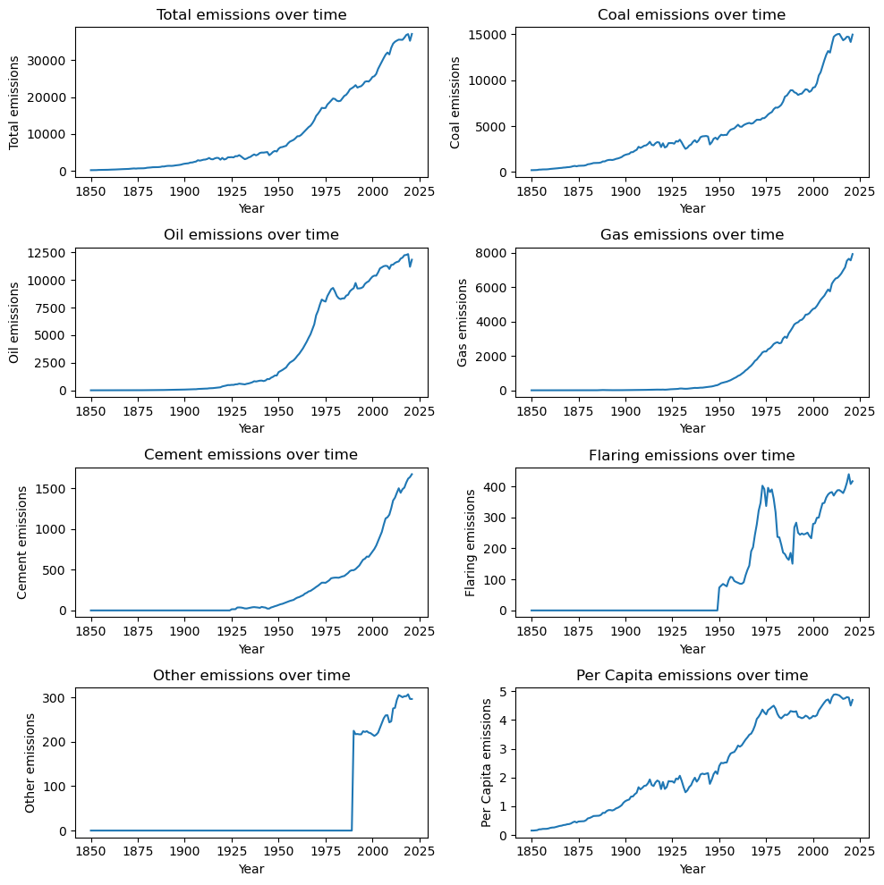

```python
emissions_data_Global = emissions_data_clean[emissions_data_clean["Country"]== "Global"]
emissions_data_Global = emissions_data_Global[emissions_data_Global['Year'] >= 1850]

fig, axs = plt.subplots(nrows=4, ncols=2, figsize=(10, 10))
axs = axs.flatten()

for i in range(len(emissions_data.columns)):
    if i > 2:
        axs[i-3].plot(emissions_data_Global['Year'], emissions_data_Global[emissions_data.columns[i]])
        axs[i-3].set_xlabel('Year')
        axs[i-3].set_ylabel(emissions_data.columns[i] + " emissions")
        axs[i-3].set_title(emissions_data.columns[i] + " emissions over time")
fig.tight_layout()
plt.show()
```

The graphs above are used to display the almost exponential increase in carbon emissions from all sources beginnning in the 20th century. It is also interesting to note the recent stablization of some sources recently, namely from coal and from coal. The per capita chart has also been added in order to illustrate how despite generally total emissions have increased over time, per capita emissions have stabilized and can serve to show how much of the growth in total emissions is not a function of higher more emission inducing consumption but rather sheer population growth.

There are two notable changes in emissions data: a sudden increase in flaring emissions around 1950, and a rise in emissions from renewable energy sources around 1985. The increase in flaring emissions can be attributed to the fact that flaring became popularized in the mid-20th century, and until 1950 no country had begun to measure emissions from this source. On the other hand, the rise in emissions from other energy sources can be attributed to the growing awareness of carbon emissions from fossil fuels, which led to the increasing popularity of renewable energy sources in the late 20th century. This rise in emissions could come from both the production of the requisite technology, such as photovoltaic cells or wind turbines, and from the production of energy itself, as is the case with biomass.

## Further Charts

```python
emissions_sorted = emissions_data_clean.groupby("Country").sum().sort_values("Total", ascending=False)
```

```python
emissions_g7 = emissions_sorted.loc[['USA', 'United Kingdom', 'Japan', 'Italy', 'France', 'Germany', 'Canada']]
emissions_g7.head()
```

| Country | Year | Total | Coal | Oil | Gas | Cement | Flaring | Other | Per Capita |
| --- | --- | --- | --- | --- | --- | --- | --- | --- | --- |
| USA | 424131 | 421906.855203 | 175444.989793 | 161275.027109 | 78542.543572 | 2795.830555 | 2421.252825 | 1427.211353 | 2252.097216 |
| United Kingdom | 512856 | 78508.720102 | 56850.597464 | 13545.630168 | 7183.232055 | 523.546615 | 290.454679 | 115.259114 | 1645.530351 |
| Japan | 299453 | 66711.083302 | 24175.925122 | 33153.129977 | 7061.825160 | 2005.370235 | 15.542080 | 299.290721 | 586.279588 |
| Italy | 314361 | 25065.176247 | 4734.375652 | 13635.770741 | 5507.858792 | 949.116333 | 95.915814 | 142.138925 | 457.104125 |
| France | 409692 | 39105.764962 | 19078.952503 | 15350.881978 | 3663.174996 | 699.426246 | 171.551305 | 141.777938 | 796.097352 |

```python
International_transport = emissions_sorted.loc[['International Transport']]
International_transport.head()
```

| Country | Year | Total | Coal | Oil | Gas | Cement | Flaring | Other | Per Capita |
| --- | --- | --- | --- | --- | --- | --- | --- | --- | --- |
| International Transport | 142956 | 43062.671846 | 0.0 | 43062.671846 | 0.0 | 0.0 | 0.0 | 0.0 | 0.0 |

```python
China_emissions = emissions_sorted.loc[['China']]
China_emissions.head()
```

| Country | Year | Total | Coal | Oil | Gas | Cement | Flaring | Other | Per Capita |
| --- | --- | --- | --- | --- | --- | --- | --- | --- | --- |
| China | 225860 | 249352.81766 | 187073.411887 | 34491.543227 | 7162.011417 | 15657.812105 | 68.487541 | 4899.55149 | 202.362414 |

```python
Rest_emissions = emissions_sorted.loc[['Global']]
transport_share = International_transport['Total'].sum()/ Rest_emissions['Total']
print(transport_share)
```

```
Country
Global    0.024792
Name: Total, dtype: float64
```

[figure not shown]

```python
share_of_g7 = emissions_g7.iloc[1:10]['Total'].sum() / Rest_emissions['Total']
transport_share = International_transport['Total'].sum() / Rest_emissions['Total']
china_share = China_emissions['Total'].sum() / Rest_emissions['Total']

labels = ['G7 Emissions Share', 'International Transport', "China Share", 'Rest of World']
sizes = [share_of_g7, transport_share, china_share, 1 - share_of_g7 - transport_share - china_share]
colors = ['#90EE90', '#FFFF00', '#FF5733', '#ADD8E6']

fig1, ax1 = plt.subplots()
ax1.pie(np.array(sizes).flatten(), colors=colors, labels=labels, startangle=90, frame=True, autopct='%1.1f%%')
fig = plt.gcf()
ax1.axis('equal')
ax1.axis('off')
plt.tight_layout()
plt.title("Shares of Total Emissions")
plt.show()
```

The chart below, helps us to visualize the changing sources of total emissions. For about 200 years, we can see that coal was the main source of emissions and by a large margin, but from around 1970 to 2000 there was a boom in oil emissions, most likely related to political events and the growing awareness of coal's consequences. However, once the 2000's hit we can again see a jump in coal emissions as a percentage of the total emissions. What nations were behind this increase in coal emissions?

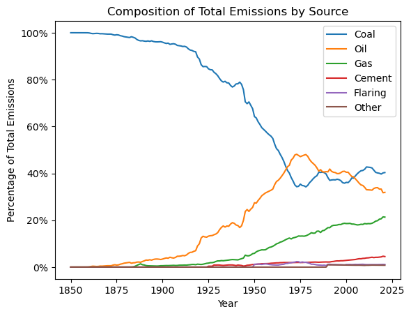

```python
emissions_filtered = emissions_data_Global[['Total','Coal', 'Oil', 'Gas', 'Cement', 'Flaring', 'Other']]

emissions_filtered = emissions_filtered.iloc[:, 1:].div(emissions_filtered.Total, axis=0) * 100

emissions_filtered = emissions_filtered.assign(Year=emissions_data_Global['Year'])

emissions_filtered.plot(x='Year', y=['Coal', 'Oil', 'Gas', 'Cement', 'Flaring', 'Other'], kind='line')

plt.title("Composition of Total Emissions by Source")

plt.ylabel("Percentage of Total Emissions")

plt.gca().yaxis.set_major_formatter(mtick.PercentFormatter())

plt.show()
```

In the tables below we are seeking to explain who are the main culprits behind coal's resurgence. We find the countries that had the largest absolute increase in coal emissions and then display them on a line graph to help illustrate the trends since 2000 and also show the differences in total emission amounts.

```python
emissions_2000 = emissions_data_clean.loc[(emissions_data_clean['Year'] == 2000), ['Country', 'Coal']]
emissions_2021 = emissions_data_clean.loc[(emissions_data_clean['Year'] == 2021), ['Country', 'Coal']]

emissions_2000_2021 = pd.merge(emissions_2000, emissions_2021, on='Country', suffixes=('_2000', '_2021'))
emissions_2000_2021
```

|  | Country | Coal_2000 | Coal_2021 |
| --- | --- | --- | --- |
| 0 | Afghanistan | 0.003664 | 4.203536 |
| 1 | Albania | 0.069531 | 0.174413 |
| 2 | Algeria | 1.960240 | 1.095536 |
| 3 | Andorra | 0.000000 | 0.000000 |
| 4 | Angola | 0.000000 | 0.000000 |
| ... | ... | ... | ... |
| 214 | Yemen | 0.000000 | 0.245909 |
| 215 | Zambia | 0.289456 | 2.463629 |
| 216 | Zimbabwe | 10.123632 | 7.225620 |
| 217 | International Transport | 0.000000 | 0.000000 |
| 218 | Global | 9203.117603 | 14979.598083 |

219 rows × 3 columns

```python
emissions_2000 = emissions_data_clean[emissions_data_clean['Year'] == 2000]
emissions_2021 = emissions_data_clean[emissions_data_clean['Year'] == 2021]
emissions_2000_2021 = pd.merge(emissions_2000, emissions_2021, on='Country', suffixes=('_2000', '_2021'))
emissions_2000_2021 = emissions_2000_2021[['Country', 'Coal_2000', 'Coal_2021']]

emissions_2000_2021['Absolute change 2000-2021'] = emissions_2000_2021['Coal_2021'] - emissions_2000_2021['Coal_2000']
emissions_2000_2021['% change 2000-2021'] = emissions_2000_2021['Absolute change 2000-2021'] / emissions_2000_2021['Coal_2000'] * 100

emissions_diff = emissions_2000_2021[['Country', 'Absolute change 2000-2021', '% change 2000-2021']]

mask = emissions_diff['Absolute change 2000-2021'] > 0
emissions_Filtered = emissions_diff[mask]
emissions_Filtered = emissions_Filtered.sort_values(by='Absolute change 2000-2021', ascending=False)
top_30 = emissions_Filtered[1:].head(30)
top_30
```

|  | Country | Absolute change 2000-2021 | % change 2000-2021 |
| --- | --- | --- | --- |
| 38 | China | 5354.248635 | 2.057952e+02 |
| 88 | India | 1229.435087 | 2.146072e+02 |
| 89 | Indonesia | 252.247563 | 4.955163e+02 |
| 212 | Viet Nam | 175.802112 | 8.486191e+02 |
| 157 | South Korea | 120.025217 | 7.323830e+01 |
| 98 | Kazakhstan | 90.319678 | 9.980208e+01 |
| 116 | Malaysia | 77.921062 | 9.896365e+02 |
| 198 | Turkey | 64.022121 | 6.497055e+01 |
| 151 | Philippines | 58.610285 | 3.595292e+02 |
| 145 | Pakistan | 51.767502 | 6.321559e+02 |
| 96 | Japan | 46.670713 | 1.254084e+01 |
| 191 | Taiwan | 44.389075 | 4.017182e+01 |
| 193 | Thailand | 40.562492 | 1.348288e+02 |
| 126 | Mongolia | 38.263531 | 6.235342e+02 |
| 180 | South Africa | 32.383459 | 9.584220e+00 |
| 129 | Morocco | 17.816421 | 1.776602e+02 |
| 26 | Brazil | 17.769454 | 3.521463e+01 |
| 103 | Laos | 15.063595 | 3.737494e+04 |
| 15 | Bangladesh | 13.599746 | 1.085299e+03 |
| 37 | Chile | 11.942953 | 8.385746e+01 |
| 204 | United Arab Emirates | 6.695359 | inf |
| 182 | Sri Lanka | 6.073005 | 1.657480e+05 |
| 192 | Tajikistan | 5.141024 | 1.169265e+04 |
| 79 | Guatemala | 4.967160 | 8.693436e+02 |
| 32 | Cambodia | 4.698298 | inf |
| 55 | Dominican Republic | 4.278528 | 1.742533e+03 |
| 0 | Afghanistan | 4.199872 | 1.146253e+05 |
| 175 | Singapore | 3.348566 | inf |
| 209 | Uzbekistan | 3.167038 | 6.441076e+01 |
| 7 | Argentina | 3.159970 | 1.907997e+02 |

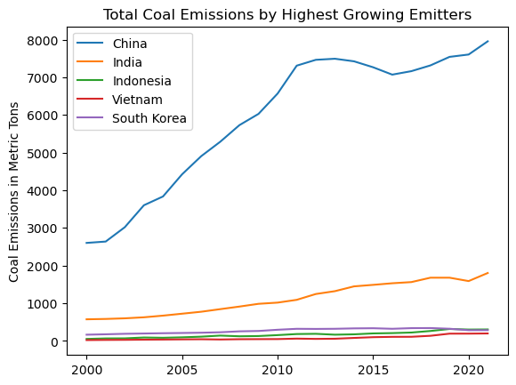

```python
emissions_data_Clean = emissions_data_clean[(emissions_data_clean['Year'] >= 2000) & (emissions_data_clean['Year'] <= 2021)]
emissions_data_Clean = emissions_data_Clean.reset_index()

emissions_china =  emissions_data_Clean[emissions_data_Clean["Country"]== "China"]
emissions_china_coal = emissions_china[["Coal", "Year"]]

emissions_india =  emissions_data_Clean[emissions_data_Clean["Country"]== "India"]
emissions_india_coal = emissions_india[["Coal", "Year"]]

emissions_indo =  emissions_data_Clean[emissions_data_Clean["Country"]== "Indonesia"]
emissions_indo_coal = emissions_indo[["Coal", "Year"]]

emissions_viet =  emissions_data_Clean[emissions_data_Clean["Country"]== "Viet Nam"]
emissions_viet_coal = emissions_viet[["Coal", "Year"]]

emissions_southk =  emissions_data_Clean[emissions_data_Clean["Country"]== "South Korea"]
emissions_southk_coal = emissions_southk[["Coal", "Year"]]

plt.plot(emissions_china_coal["Year"], emissions_china_coal["Coal"], label="China")
plt.plot(emissions_india_coal["Year"], emissions_india_coal["Coal"], label="India")
plt.plot(emissions_indo_coal["Year"], emissions_indo_coal["Coal"], label="Indonesia")
plt.plot(emissions_viet_coal["Year"], emissions_viet_coal["Coal"], label="Vietnam")
plt.plot(emissions_southk_coal["Year"], emissions_southk_coal["Coal"], label="South Korea")

plt.title("Total Coal Emissions by Highest Growing Emitters")
plt.ylabel("Coal Emissions in Metric Tons")
plt.legend()
plt.show()
```

China is the biggest culprit behind the coal increases in the past 20 years. In fact, according to the Center for Research on Energy and Clean Air, China is building six times more coal plants than the rest of the world combined ((Myllyvirta et al., China permits two new coal power plants per week in 2022 2023 https://energyandcleanair.org/publication/china-permits-two-new-coal-power-plants-per-week-in-2022/)). Despite this, China is still decreasing the proportion of its energy mix which is accounted for by coal emissions (U.S. Energy Information Administration - EIA - independent statistics and analysis 2022 https://www.eia.gov/international/analysis/country/CHN).

One of the challenges facing China and other countries on the list (with the exception of South Korea) is that as they develop and their economies grow, their energy consumption also increases. Coal has traditionally been a cheap and abundant source of energy, and many countries have turned to it to meet their growing energy needs. Despite its negative impact on the environment and human health, coal has been viewed as a reliable and secure source of energy by some countries, leading to its continued use even as renewable energy alternatives become more available.

# Project Two

## 2.1 Message

The primary objective of this project component is to integrate household size statistics to investigate the correlation between this variable and the previously analyzed carbon emissions. The initial step will involve measuring the relationship between household size and total emissions, followed by examining the correlation between household size in each country and the emissions it produces the most. Finally, countries will be categorized based on specific characteristics to evaluate whether economic conditions and per capita emissions contribute to varying effects of household size on emissions.

```python
merged_df['Average household size (number of members)'] = pd.to_numeric(
    merged_df['Average household size (number of members)'], errors='coerce')
merged_df['Per Capita'] = pd.to_numeric(merged_df['Per Capita'], errors='coerce')
```

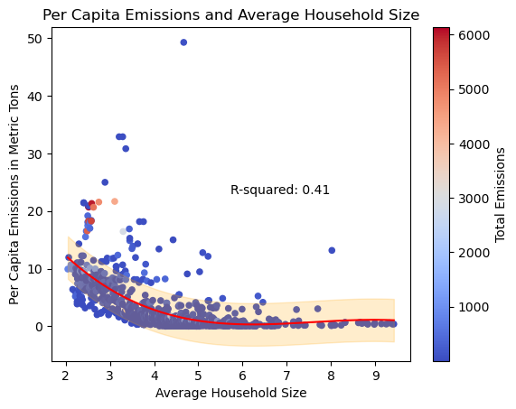

```python
merged_df = merged_df.sort_values('Average household size (number of members)')
merged_df = merged_df.rename(columns={'Total':"Total Emissions"})
merged_df.plot.scatter(x = 'Average household size (number of members)', y = 'Per Capita', c = 'Total Emissions', cmap = 'coolwarm')
x = merged_df['Average household size (number of members)'].values
y = merged_df['Per Capita'].values


# add polynomial fit and error band
p = np.polyfit(x, y, 3)
f = np.poly1d(p)
y_pred = np.polyval(p, x)
residuals = y - y_pred
std_error = np.std(residuals)
plt.plot(x, f(x), 'r')
plt.fill_between(x, y_pred-std_error, y_pred+std_error, alpha=0.2, color='orange')

# calculate R-squared
y_mean = np.mean(y)
ss_tot = np.sum((y - y_mean)**2)
ss_res = np.sum(residuals**2)
r_squared = 1 - ss_res / ss_tot

# set labels and title
plt.xlabel('Average Household Size')
plt.ylabel('Per Capita Emissions in Metric Tons')
plt.title('Per Capita Emissions and Average Household Size')

# add R-squared value to plot
plt.text(0.5, 0.5, f"R-squared: {r_squared:.2f}", transform=plt.gca().transAxes)

plt.savefig('Regression Graph')
plt.show()
```

This effect could exist because of actual house size or endogeneity with per capita GDP. For the first possibility, as described in Katherine Kellsworth-Krebs 2019 paper (Ellsworth-Krebs, Katherine. “Implications of declining household sizes and expectations of home comfort for domestic energy demand.” Nature Energy 5 (2019): 20-25.), the apparent relationship household size has with carbon emissions, may be due more to house size than density. Kellsworth-Krebs found that energy efficiency gains from home maintenance have been offset by the trend of increasing house sizes and energy-intensive lifestyles, particularly among single and couple households in suburban areas with rising housing prices. The main driver of this energy intensive lifestyle has been single and couple housing, as due to the rising trend of subarbanization and rising city housing prices, these populations are buyingg bigger and bigger houses relative to what they were buying before.

The second possible reason for this relationship could be that many richer countries tend to, for cultural and economic reasons, have citizens that tend to live in smaller groups. In Kellsworth-Krebs' study she looks at the changing attitudes in the Japanese population whereby in the 1950's 60% of women expected to be taken care of by their children, which most of the time was done through cohabitation, while fourty years later this number was 16%. This means that rich countries tend to emit more, but also tend to have smaller households and so the effect of that wealth has on emissions is being captured here by household size serving as a proxy.

```python
averagehousehold_g7 = merged_df.loc[['USA', 'United Kingdom', 'Japan', 'Italy', 'France', 'Germany']]
```

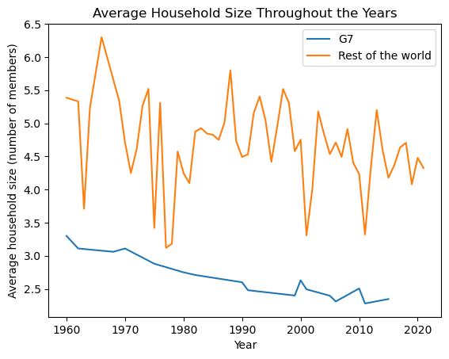

```python
g7_countries = ['USA', 'United Kingdom', 'Japan', 'Italy', 'France', 'Germany']
g7_data = merged_df.loc[g7_countries]

rest_data = merged_df.loc[~merged_df.index.isin(g7_countries)]

g7_mean = g7_data.groupby('Year')['Average household size (number of members)'].mean()
rest_mean = rest_data.groupby('Year')['Average household size (number of members)'].mean()

plt.plot(g7_mean.index, g7_mean, label='G7')
plt.plot(rest_mean.index, rest_mean, label='Rest of the world')

plt.xlabel('Year')
plt.ylabel('Average household size (number of members)')
plt.legend()
plt.title('Average Household Size Throughout the Years')
plt.show()
```

We can also see a spike in CO2 emissions from the rest of the world which can partly be explained by the end of the communist revolution in China and the beginning of rapid industrialization in the country, with a 26% increase in emissions from 1949 to 1950. In addition, 1950 was the first year emissions data was available for many developing countries, which also contributed to a small peak at 1950.

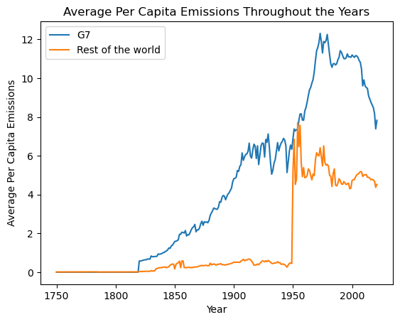

```python
Emissions_data_clean = emissions_data_clean.set_index('Country')
g7_countries = ['USA', 'United Kingdom', 'Japan', 'Italy', 'France', 'Germany']
g7_data = Emissions_data_clean.loc[g7_countries]

rest_data = Emissions_data_clean.loc[~(Emissions_data_clean.index.isin(g7_countries))]
rest_data = rest_data.loc[~(rest_data.index == "International Transport")]


g7_mean = g7_data.groupby('Year')['Per Capita'].mean()
rest_mean = rest_data.groupby('Year')['Per Capita'].mean()

plt.plot(g7_mean.index, g7_mean, label='G7')
plt.plot(rest_mean.index, rest_mean, label='Rest of the world')

plt.xlabel('Year')
plt.ylabel('Average Per Capita Emissions')
plt.legend()
plt.title('Average Per Capita Emissions Throughout the Years')
plt.show()
```

## 2.2 Maps and Interpretation

Below are two maps. The first showing the distribution of coal emissions and the second displaying average household size in the most recent year the data was collected.

The share of coal among total emissions is displayed, in order to better understand the relationship between carbon emissions and economic conditions. This was shown on the micro level in South Africa in Balmer's 2017 study of household coal use in urban South Africa (Balmer, M. (2017). Household coal use in an urban township in South Africa. Journal of Energy in Southern Africa, 18, 27-32.).

The second map is to display the average household size to see how it matches the previous coal emissions map. If we see a trend of countries that are both high in terms of carbon emissions and average household size, then it'll serve to reinforce Balmer's theory on a macro scale. Namely, bigger households burn more coal due to the need to generate more energy than what the state allots. On the other hand, the opposite relationship may be true as well where smaller households consume more, not because household size is directly correlated with emissions but rather because it is correlated with wealth and wealth is correlated with emissions. In further research this relationship will be refined through different empirical methods such as IV tests or a Diff and Diff analysis.

```python
world = gpd.read_file(gpd.datasets.get_path("naturalearth_lowres"))
world = world.set_index("name")

world.head()
```

| name | pop_est | continent | iso_a3 | gdp_md_est | geometry |
| --- | --- | --- | --- | --- | --- |
| Fiji | 889953.0 | Oceania | FJI | 5496 | MULTIPOLYGON (((180.00000 -16.06713, 180.00000... |
| Tanzania | 58005463.0 | Africa | TZA | 63177 | POLYGON ((33.90371 -0.95000, 34.07262 -1.05982... |
| W. Sahara | 603253.0 | Africa | ESH | 907 | POLYGON ((-8.66559 27.65643, -8.66512 27.58948... |
| Canada | 37589262.0 | North America | CAN | 1736425 | MULTIPOLYGON (((-122.84000 49.00000, -122.9742... |
| United States of America | 328239523.0 | North America | USA | 21433226 | MULTIPOLYGON (((-122.84000 49.00000, -120.0000... |

```python
emissions_data["ISO 3166-1 alpha-3"] = emissions_data["ISO 3166-1 alpha-3"].str.title()
emissions_data["ISO 3166-1 alpha-3"] = emissions_data["ISO 3166-1 alpha-3"].str.strip()
world["iso_a3"] = world["iso_a3"].str.title()
world["iso_a3"] = world["iso_a3"].str.strip()
country_emissions = world.merge(emissions_data, left_on="iso_a3", right_on="ISO 3166-1 alpha-3", how="inner")
country_emissions["Coal Share"] = country_emissions["Coal"] / (country_emissions["Total"])
```

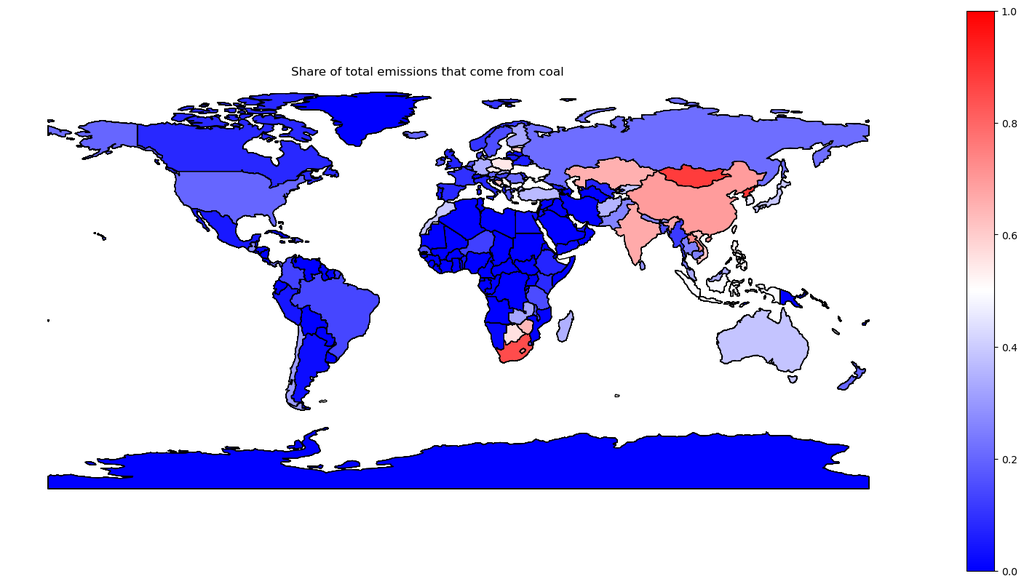

```python
fig, gax = plt.subplots(figsize = (20,20))
gax.set_xlabel('longitude')
gax.set_ylabel('latitude')

world.plot(ax=gax, edgecolor='black',color='white')

country_emissions.plot(
    ax=gax, edgecolor='black', column='Coal Share', legend=True, cmap='bwr', legend_kwds={"shrink": 0.5},
    vmin=0, vmax=1
)

gax.annotate('Share of total emissions that come from coal',xy=(0.2, 0.35),fontsize='large', xycoords='figure fraction')

plt.axis('off')

plt.show()
```

```python
max_years = household_data.groupby(['Country'])['Year'].max()
max_years = max_years.to_frame().rename(columns= {'Year':'Max_Year'})
```

```python
household_data = pd.merge(household_data,max_years, how = 'left', on='Country')
```

```python
household_data_max_year = household_data[household_data.Year==household_data.Max_Year]
```

```python
world_household = pd.merge(household_data_max_year, world, left_index=True, right_index=True)
```

[output not shown]

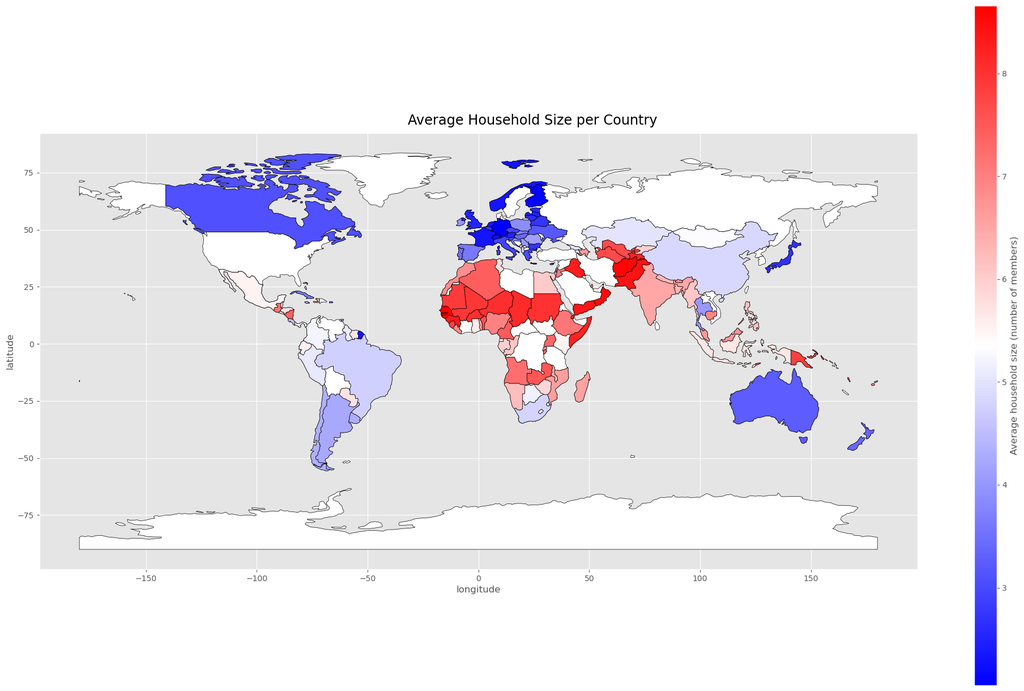

```python
gdf = gpd.GeoDataFrame(world_household, geometry= "geometry")
fig, gax = plt.subplots(figsize = (20,20))
gax.set_xlabel('longitude')
gax.set_ylabel('latitude')

world.plot(ax=gax, edgecolor='black',color='white')

gdf.plot(
    ax=gax, edgecolor='black', column='Average household size (number of members)', cmap='bwr', legend=False)

fig = plt.gcf()
cax = fig.add_axes([0.95, 0.2, 0.02, 0.6]) # x, y, width, height
vmin = gdf['Average household size (number of members)'].min()
vmax = gdf['Average household size (number of members)'].max()
sm = plt.cm.ScalarMappable(cmap='bwr', norm=plt.Normalize(vmin=vmin, vmax=vmax))
sm._A = []
cbar=fig.colorbar(sm, cax=cax)
cbar.ax.set_ylabel('Average household size (number of members)')
gax.annotate('Average Household Size per Country',xy=(0.36, 0.5),fontsize='xx-large', xycoords='figure fraction')
warnings.filterwarnings("ignore")
cbar.ax.set_yticklabels(['{:.2f}'.format(vmin), '{:.2f}'.format(vmax)])
plt.axis('off')

plt.show()
```

# Project Three

## 3.1 Potential Data to Scrape

To investigate the impact of household size on carbon emissions and potentially build upon the Kellsworth-Krebs findings, I plan to incorporate floor area per capita data into my analysis. I will run a regression analysis that controls for both square footage per capita and GDP per capita, with the latter being easier to obtain through dataset or web scraping. This will allow me to isolate the effect of household size on carbon emissions.

To collect floor size per capita, I will scrape information from the websites of various national agencies or real estate websites to gain a better understanding of the factors involved, including historical data. However, despite the abundant sources of data available on the internet, it may be challenging to find consistent and accurate data, particularly in developing countries where house construction is comparatively less regulated, and records pertaining to house size and average occupancy may be scarce.

In terms of merging, I will merge the floor area per capita data with the existing dataset that already includes household size and emissions. The merging will be based on year and country. I will eliminate any data that isn't represented in any of the three datasets to avoid any errors in the regression analysis. Given the large amount of data available, it is expected that the final dataset will contain more than the required 500 observations for a regression analysis.

## 3.2 Potential Challenges

Several potential challenges may arise with this scraping initiative, including the sheer number of websites that I would need to scrape from, as well as the different metrics and missing data that I may need to collect myself or obtain using satellite data.

The first issue is self-explanatory. Since there are approximately 200 countries, I would need to gather data from multiple governmental and national real estate websites. Some of these websites also collect their information through self-reported surveys, which may contain imprecise information or may be innacurate due to realtively small sample sizes. Moreover, much of this data is collected sparsely, making it difficult to obtain.

Lastly, availability may also pose a challenge. While many countries have data on population density, household size, and housing units, unit size or floor area per capita data may not be readily available. As such, original data collection may need to be done through surveys of residents or construction firms, or rough estimates may need to be made by examining satellite data and population density in a particular region.

## 3.3 Scraping the Data

Instead of embarking on the gargantuan task of collecting enough floor are per capita that would suffice to find a robust relationship i'll scrape GDP per Capita data off of Wikipedia and then add a population density dataset to the dataframe.

We'll be using the IMF data from this link ("https://en.wikipedia.org/wiki/List_of_countries_by_past_and_projected_GDP_(nominal)_per_capita") which corresponds to the first four tables on the site. This will gives us each nations gdp per capita for every year from 1980-2019.

```python
URL = 'https://en.wikipedia.org/wiki/List_of_countries_by_past_and_projected_GDP_(nominal)_per_capita'

# Connect to the URL
Response = requests.get(URL)

# Parse HTML and save to BeautifulSoup object¶
largest_soup = BeautifulSoup(Response.text, "html.parser") #html.parser telling Beautiful Soup that it's an HTML file
```

```python
# Here we will be trying to find the tables in the HTML file by finding the first table classified as "wikitable"
# Using IMF data, so need to take only the first four tables, as opposed to all of the tables on the site
Table_8089 = largest_soup.find_all('table', {'class': 'wikitable'})[0]
header_row = Table_8089.find('tr')
columns = [col.get_text(strip=True) for col in header_row.find_all('th')]
```

```python
# Here we're finding all the rows in the first table and for each row we're populating the column with 'td'
# which is the content in each row
rows = Table_8089.find_all('tr')[1:]
data = []
for row in rows:
    cols = row.find_all('td')
    cols = [col.text.strip() for col in cols]
    data.append(cols)

df_8089 = pd.DataFrame(data, columns=columns)
```

```python
# Given we have 4 IMF tables we're trying to merge we're doing this process again, this time it's for the years 1990-1999
Table_9099 = largest_soup.find_all('table', {'class': 'wikitable'})[1]
header_row = Table_9099.find('tr')
columns = [col.get_text(strip=True) for col in header_row.find_all('th')]

rows = Table_9099.find_all('tr')[1:]
data = []
for row in rows:
    cols = row.find_all('td')
    cols = [col.text.strip() for col in cols]
    data.append(cols)

df_9099 = pd.DataFrame(data, columns=columns)
```

```python
# Now for 2000-2009
Table_0009 = largest_soup.find_all('table', {'class': 'wikitable'})[2]
header_row = Table_0009.find('tr')
columns = [col.get_text(strip=True) for col in header_row.find_all('th')]

rows = Table_0009.find_all('tr')[1:]
data = []
for row in rows:
    cols = row.find_all('td')
    cols = [col.text.strip() for col in cols]
    data.append(cols)

df_0009 = pd.DataFrame(data, columns=columns)
```

```python
# Finally for 2009-2019, note that we're creating different dataframes for the different IMF tables on the site
Table_1019 = largest_soup.find_all('table', {'class': 'wikitable'})[3]
header_row = Table_1019.find('tr')
columns = [col.get_text(strip=True) for col in header_row.find_all('th')]

rows = Table_1019.find_all('tr')[1:]
data = []
for row in rows:
    cols = row.find_all('td')
    cols = [col.text.strip() for col in cols]
    data.append(cols)

df_1019 = pd.DataFrame(data, columns=columns)
```

```python
# Now we'll merge all the dataframes

Merged_df = pd.merge(df_8089, df_9099, on= "Country (or dependent territory)")
Merged_df = pd.merge(Merged_df, df_0009, on= "Country (or dependent territory)")
Merged_df = pd.merge(Merged_df, df_1019, on= "Country (or dependent territory)")

Merged_df = Merged_df.rename(columns = {"Country (or dependent territory)": "Country"})
Merged_df = Merged_df.set_index("Country")
Merged_df.rename(index={'United States': 'USA'}, inplace=True)
Merged_df = Merged_df.reset_index(drop=False)
```

## 3.4 Merging

First I will merge the data with the original, cleaned emissions dataset, then will merge with the dataset containing household size as well.

Given the merged dataframe has the years as the columns instead of column values we'll use pd.melt to create a new "Year" column containing the different years they collected the data for.

```python
melted_df = pd.melt(Merged_df, id_vars=['Country'], var_name='Year', value_name='GDP Per Capita')
melted_df['Year'] = melted_df['Year'].astype('int64')
melted_df
```

|  | Country | Year | GDP Per Capita |
| --- | --- | --- | --- |
| 0 | Afghanistan | 1980 |  |
| 1 | Albania | 1980 | 728 |
| 2 | Algeria | 1980 | 2,269 |
| 3 | Andorra | 1980 |  |
| 4 | Angola | 1980 | 803 |
| ... | ... | ... | ... |
| 7835 | Vietnam | 2019 | 3,439 |
| 7836 | Palestine | 2019 | 3,443 |
| 7837 | Yemen | 2019 | 702 |
| 7838 | Zambia | 2019 | 1,268 |
| 7839 | Zimbabwe | 2019 | 1,747 |

7840 rows × 3 columns

```python
emerged_df = pd.merge(emissions_data_clean, melted_df, on=['Country', 'Year'])
emerged_df = emerged_df[emerged_df['GDP Per Capita'] != "—"]

emerged_df
```

|  | Country | ISO 3166-1 alpha-3 | Year | Total | Coal | Oil | Gas | Cement | Flaring | Other | Per Capita | GDP Per Capita |
| --- | --- | --- | --- | --- | --- | --- | --- | --- | --- | --- | --- | --- |
| 0 | Afghanistan | AFG | 1980 | 1.756302 | 0.315762 | 0.925256 | 0.187254 | 0.023284 | 0.304747 | 0.0 | 0.140655 |  |
| 1 | Afghanistan | AFG | 1981 | 1.978463 | 0.333424 | 1.014928 | 0.304112 | 0.032879 | 0.293120 | 0.0 | 0.177358 |  |
| 2 | Afghanistan | AFG | 1982 | 2.094581 | 0.384720 | 0.992944 | 0.395712 | 0.039077 | 0.282128 | 0.0 | 0.207625 |  |
| 3 | Afghanistan | AFG | 1983 | 2.519954 | 0.384720 | 1.220112 | 0.615552 | 0.006450 | 0.293120 | 0.0 | 0.253225 |  |
| 4 | Afghanistan | AFG | 1984 | 2.821540 | 0.392556 | 1.133644 | 0.931863 | 0.047963 | 0.315513 | 0.0 | 0.275442 |  |
| ... | ... | ... | ... | ... | ... | ... | ... | ... | ... | ... | ... | ... |
| 7265 | Zimbabwe | ZWE | 2015 | 12.254954 | 8.060800 | 3.609040 | 0.000000 | 0.585114 | 0.000000 | 0.0 | 0.865772 | 1,425 |
| 7266 | Zimbabwe | ZWE | 2016 | 10.533453 | 6.932288 | 3.140048 | 0.000000 | 0.461117 | 0.000000 | 0.0 | 0.728822 | 1,445 |
| 7267 | Zimbabwe | ZWE | 2017 | 9.596071 | 5.900452 | 3.226752 | 0.000000 | 0.468867 | 0.000000 | 0.0 | 0.650533 | 1,481 |
| 7268 | Zimbabwe | ZWE | 2018 | 11.795478 | 7.177776 | 4.059712 | 0.000000 | 0.557990 | 0.000000 | 0.0 | 0.783639 | 2,523 |
| 7269 | Zimbabwe | ZWE | 2019 | 11.114607 | 6.888320 | 3.656672 | 0.000000 | 0.569615 | 0.000000 | 0.0 | 0.723861 | 1,747 |

7270 rows × 12 columns

## 3.5 Visualizations

The former will represent a refining of previous data, using G7 status as a proxy for wealth. It'll also provide a representation of how the composition of total emissions has been changing, according to the wealth of the nation. The bin sizes were chosen to correspond with the relative size of the G7.

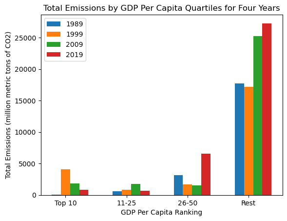

```python
years = [1989, 1999, 2009, 2019]
y1989 = emerged_df[emerged_df['Year']==1989].sort_values(by = ['GDP Per Capita'], ascending = [False])
y1999 = emerged_df[emerged_df['Year']==1999].sort_values(by = ['GDP Per Capita'], ascending = [False])
y2009 = emerged_df[emerged_df['Year']==2009].sort_values(by = ['GDP Per Capita'], ascending = [False])
y2019 = emerged_df[emerged_df['Year']==2019].sort_values(by = ['GDP Per Capita'], ascending = [False])

top_10_89= y1989[:10]
top_10_99= y1999[:10]
top_10_09= y2009[:10]
top_10_19= y2019[:10]

top_1025 = y1989[10:25]
top_1025_99 = y1999[10:25]
top_1025_09 = y2009[10:25]
top_1025_19 = y2019[10:25]

top_2550 = y1989[25:50]
top_2550_99 = y1999[25:50]
top_2550_09 = y2009[25:50]
top_2550_19 = y2019[25:50]

rest_89 = y1989[50:]
rest_99 = y1999[50:]
rest_09 = y2009[50:]
rest_19 = y2019[50:]

# Create data for stacked bars
emissions_89 = [sum(top_10_89['Total']), sum(top_1025['Total']), sum(top_2550['Total']), sum(rest_89['Total'])]
emissions_99 = [sum(top_10_99['Total']), sum(top_1025_99['Total']), sum(top_2550_99['Total']), sum(rest_99['Total'])]
emissions_09 = [sum(top_10_09['Total']), sum(top_1025_09['Total']), sum(top_2550_09['Total']), sum(rest_09['Total'])]
emissions_19 = [sum(top_10_19['Total']), sum(top_1025_19['Total']), sum(top_2550_19['Total']), sum(rest_19['Total'])]

# Create labels for the x-axis and each stack
labels = ['Top 10', '11-25', '26-50', 'Rest']

# Set up the figure and axes
fig, ax = plt.subplots()

# Set up the positions and width of each bar
bar_positions = np.arange(len(labels))
bar_width = 0.15

# Create the stacked bars for each year
ax.bar(bar_positions - bar_width, emissions_89, bar_width, label='1989')
ax.bar(bar_positions, emissions_99, bar_width, label='1999')
ax.bar(bar_positions + bar_width, emissions_09, bar_width, label='2009')
ax.bar(bar_positions + 2*bar_width, emissions_19, bar_width, label='2019')

# Add labels and title
ax.set_xlabel('GDP Per Capita Ranking')
ax.set_ylabel('Total Emissions (million metric tons of CO2)')
ax.set_title('Total Emissions by GDP Per Capita Quartiles for Four Years')
ax.set_xticks(bar_positions)
ax.set_xticklabels(labels)
ax.legend()

# Show the plot
plt.show()
```

It appears that the inequality of emissions discussed earlier is currently decreasing, as poorer countries contribute more to the total emissions. This trend aligns with Schipper, Ting et al.'s 1997 study, which explored the decrease in energy use per capita in developed nations (Schipper, L., Ting, M., Khrushch, M., Unander, F., Monahan, P.A., & Golove, W. (1996)). The evolution of carbon dioxide emissions from energy use in industrialized countries: an end-use analysis). This trend continued well into the 90s, despite increased growth in GDP. The reasons for this trend include the ability of industrialized nations to transition more easily into renewable energy source development, as well as growing consciousness around the issue.

Nevertheless, this may also be due to other unrelated factors, such as the rise in per capita wealth of micro-states, both in europe (such as Lichtenstein, Monaco, Luxembourg) as well as in Asia (Qatar, UAE, Bahrain) that although very wealthy, have low total emissions because of their size.

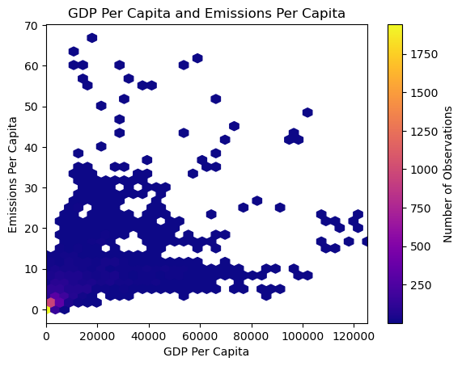

```python
emerged_df.dropna(inplace=True)
emerged_df = emerged_df.replace(',', '', regex=True)

# Convert 'GDP Per Capita' column to numeric type
emerged_df['GDP Per Capita'] = pd.to_numeric(emerged_df['GDP Per Capita'], errors='coerce')

# Remove any rows with missing values in 'GDP Per Capita' column
emerged_df.dropna(subset=['GDP Per Capita'], inplace=True)

x = emerged_df['GDP Per Capita']
y = emerged_df['Per Capita']
xmin = 0
xmax= x.max()

fig, ax = plt.subplots()
plt.hexbin(x, y, gridsize=35, cmap="plasma", mincnt = 1)
ax.set_xlim(xmin, xmax)
# Set axis labels and title
ax.set_xlabel('GDP Per Capita')
ax.set_ylabel('Emissions Per Capita')
ax.set_title('GDP Per Capita and Emissions Per Capita')

plt.colorbar().set_label('Number of Observations')
plt.show()
```

To explore this further, we created a similar graph for a single year and observed a similar relationship between GDP per capita and emissions per capita. However, the numbers were small enough for the relationship to be considered noise and not statistically significant. These charts serve mainly to illustrate the main message that GDP per capita has *some* effect on emissions per capita, but further statistical analysis is required to establish the magnitude of the effect, which will be performed in this report.

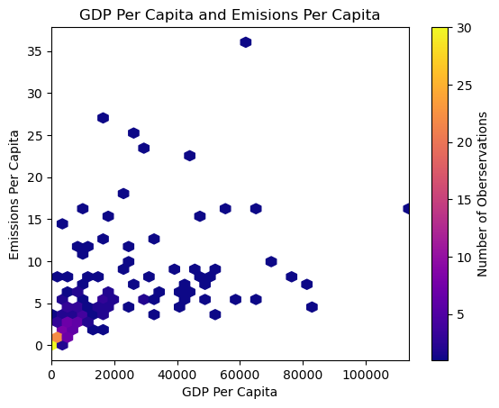

```python
emerged_df.dropna(inplace=True)
emerged_df = emerged_df.replace(',', '', regex=True)
df_2019 = emerged_df[emerged_df['Year'] == 2019]


x = df_2019['GDP Per Capita']
y = df_2019['Per Capita']
xmin = 0
xmax= x.max()

fig, ax = plt.subplots()
plt.hexbin(x, y, gridsize=35, cmap="plasma", mincnt = 1)
ax.set_xlim(xmin, xmax)
# Set axis labels and title
ax.set_xlabel('GDP Per Capita')
ax.set_ylabel('Emissions Per Capita')
ax.set_title('GDP Per Capita and Emisions Per Capita')

plt.colorbar().set_label('Number of Oberservations')
plt.show()
```

## 3.6 Adding another Dataset

Given our study's objective of determining whether a significant relationship exists between household size and carbon emissions, it's essential to introduce population density data in our regression analysis to control for its effects. This will enable us to isolate the effect of household size on carbon emissions and determine whether it's a significant factor or whether household size is serving as a proxy for other variables such as GDP per capita and/or density.

It's important to note that density is distinct from household size as it doesn't capture the housing unit situation or actual living conditions in a country. For instance, a country like Algeria may have a low population density due to the desert nature of its landscape, but may have a high household size due to dense living in arable land. Therefore, controlling for density in our analysis is critical to accurately assess the impact of household size on carbon emissions.

```python
# We're going to data scrape again, as it's easier than going through the UN's very thorough datasets

URL = 'https://en.wikipedia.org/wiki/List_of_countries_by_past_and_future_population_density'

# Connect to the URL
Response = requests.get(URL)

# Parse HTML and save to BeautifulSoup object¶
largest_soup = BeautifulSoup(Response.text, "html.parser") #html.parser telling Beautiful Soup that it's an HTML file

data_Table = largest_soup.find_all('table', {'class': 'wikitable'})[0]
header_row = data_Table.find('tr')
columns = [col.get_text(strip=True) for col in header_row.find_all('th')]

rows = data_Table.find_all('tr')[1:]
data = []
for row in rows:
    cols = row.find_all('td')
    cols = [col.text.strip() for col in cols]
    data.append(cols)

pop_den = pd.DataFrame(data, columns=columns)
pop_den.rename(columns = {'Country (or area)': 'Country'}, inplace = True)
pop_den['Country'] = pop_den['Country'].str.replace('*', '')

pop_den
```

|  | Country | 1950 | 1960 | 1970 | 1980 | 1990 | 2000 | 2010 | 2018 |
| --- | --- | --- | --- | --- | --- | --- | --- | --- | --- |
| 0 | Afghanistan | 11.9 | 13.8 | 17.0 | 20.3 | 18.8 | 30.8 | 44.1 | 55.7 |
| 1 | Albania | 46.1 | 59.7 | 78.5 | 97.9 | 119.8 | 113.9 | 107.3 | 107.1 |
| 2 | Algeria | 3.7 | 4.7 | 6.1 | 8.1 | 10.9 | 13.1 | 15.2 | 17.6 |
| 3 | American Samoa (USA) | 94.7 | 100.1 | 136.5 | 162.3 | 235.2 | 287.6 | 278.2 | 278.4 |
| 4 | Andorra | 13.2 | 28.5 | 51.7 | 76.7 | 116.0 | 139.1 | 179.7 | 163.7 |
| ... | ... | ... | ... | ... | ... | ... | ... | ... | ... |
| 227 | Wallis and Futuna (France) | 50.0 | 61.1 | 63.2 | 80.2 | 99.1 | 103.6 | 95.9 | 83.4 |
| 228 | Western Sahara [7] | 0.1 | 0.1 | 0.3 | 0.6 | 0.8 | 1.2 | 1.8 | 2.1 |
| 229 | Yemen | 8.3 | 9.8 | 11.7 | 15.4 | 22.8 | 33.9 | 44.7 | 54.8 |
| 230 | Zambia | 3.1 | 4.1 | 5.6 | 7.9 | 10.8 | 14.2 | 18.6 | 23.7 |
| 231 | Zimbabwe | 7.1 | 9.7 | 13.4 | 18.5 | 26.3 | 31.6 | 36.4 | 43.7 |

232 rows × 9 columns

```python
Melted_df = pd.melt(pop_den, id_vars=['Country'], var_name='Year', value_name='Population Density')
Melted_df['Year'] = Melted_df['Year'].astype('int64')
Melted_df['Country']= Melted_df['Country'].astype('str')
Melted_df['Country']= Melted_df['Country'].str.strip()
Emerged_df = pd.merge(emerged_df, Melted_df, on=['Country', 'Year']) #creating dataset with all categories
Emerged_df = Emerged_df.replace(',', '', regex=True)
```

```python
Emerged_df
```

|  | Country | ISO 3166-1 alpha-3 | Year | Total | Coal | Oil | Gas | Cement | Flaring | Other | Per Capita | GDP Per Capita | Population Density |
| --- | --- | --- | --- | --- | --- | --- | --- | --- | --- | --- | --- | --- | --- |
| 0 | Afghanistan | AFG | 2010 | 8.364803 | 2.246032 | 5.833088 | 0.271136 | 0.014547 | 0.0 | 0.0 | 0.296733 | 631.0 | 44.1 |
| 1 | Afghanistan | AFG | 2018 | 10.818048 | 3.847200 | 6.620848 | 0.293120 | 0.056880 | 0.0 | 0.0 | 0.294876 | 582.0 | 55.7 |
| 2 | Albania | ALB | 1980 | 5.170837 | 2.322976 | 1.571856 | 0.773104 | 0.502901 | 0.0 | 0.0 | 1.757801 | 728.0 | 97.9 |
| 3 | Albania | ALB | 1990 | 5.520602 | 2.498848 | 2.172752 | 0.465328 | 0.383674 | 0.0 | 0.0 | 1.675415 | 676.0 | 119.8 |
| 4 | Albania | ALB | 2000 | 3.024926 | 0.069531 | 2.839801 | 0.021957 | 0.093637 | 0.0 | 0.0 | 0.950630 | 1128.0 | 113.9 |
| ... | ... | ... | ... | ... | ... | ... | ... | ... | ... | ... | ... | ... | ... |
| 772 | Zambia | ZMB | 2018 | 7.412041 | 2.744336 | 3.601712 | 0.000000 | 1.065993 | 0.0 | 0.0 | 0.415569 | 1475.0 | 23.7 |
| 773 | Zimbabwe | ZWE | 1990 | 15.551593 | 13.417568 | 1.846656 | 0.000000 | 0.287369 | 0.0 | 0.0 | 1.537647 | 1037.0 | 26.3 |
| 774 | Zimbabwe | ZWE | 2000 | 13.818202 | 10.123632 | 3.290272 | 0.000000 | 0.404298 | 0.0 | 0.0 | 1.167603 | 970.0 | 31.6 |
| 775 | Zimbabwe | ZWE | 2010 | 8.754012 | 6.507264 | 1.938256 | 0.000000 | 0.308492 | 0.0 | 0.0 | 0.681789 | 976.0 | 36.4 |
| 776 | Zimbabwe | ZWE | 2018 | 11.795478 | 7.177776 | 4.059712 | 0.000000 | 0.557990 | 0.0 | 0.0 | 0.783639 | 2523.0 | 43.7 |

777 rows × 13 columns

```python
Emerged_df["Population Density"] = Emerged_df["Population Density"].astype('float64')
Emerged_df
```

|  | Country | ISO 3166-1 alpha-3 | Year | Total | Coal | Oil | Gas | Cement | Flaring | Other | Per Capita | GDP Per Capita | Population Density |
| --- | --- | --- | --- | --- | --- | --- | --- | --- | --- | --- | --- | --- | --- |
| 0 | Afghanistan | AFG | 2010 | 8.364803 | 2.246032 | 5.833088 | 0.271136 | 0.014547 | 0.0 | 0.0 | 0.296733 | 631.0 | 44.1 |
| 1 | Afghanistan | AFG | 2018 | 10.818048 | 3.847200 | 6.620848 | 0.293120 | 0.056880 | 0.0 | 0.0 | 0.294876 | 582.0 | 55.7 |
| 2 | Albania | ALB | 1980 | 5.170837 | 2.322976 | 1.571856 | 0.773104 | 0.502901 | 0.0 | 0.0 | 1.757801 | 728.0 | 97.9 |
| 3 | Albania | ALB | 1990 | 5.520602 | 2.498848 | 2.172752 | 0.465328 | 0.383674 | 0.0 | 0.0 | 1.675415 | 676.0 | 119.8 |
| 4 | Albania | ALB | 2000 | 3.024926 | 0.069531 | 2.839801 | 0.021957 | 0.093637 | 0.0 | 0.0 | 0.950630 | 1128.0 | 113.9 |
| ... | ... | ... | ... | ... | ... | ... | ... | ... | ... | ... | ... | ... | ... |
| 772 | Zambia | ZMB | 2018 | 7.412041 | 2.744336 | 3.601712 | 0.000000 | 1.065993 | 0.0 | 0.0 | 0.415569 | 1475.0 | 23.7 |
| 773 | Zimbabwe | ZWE | 1990 | 15.551593 | 13.417568 | 1.846656 | 0.000000 | 0.287369 | 0.0 | 0.0 | 1.537647 | 1037.0 | 26.3 |
| 774 | Zimbabwe | ZWE | 2000 | 13.818202 | 10.123632 | 3.290272 | 0.000000 | 0.404298 | 0.0 | 0.0 | 1.167603 | 970.0 | 31.6 |
| 775 | Zimbabwe | ZWE | 2010 | 8.754012 | 6.507264 | 1.938256 | 0.000000 | 0.308492 | 0.0 | 0.0 | 0.681789 | 976.0 | 36.4 |
| 776 | Zimbabwe | ZWE | 2018 | 11.795478 | 7.177776 | 4.059712 | 0.000000 | 0.557990 | 0.0 | 0.0 | 0.783639 | 2523.0 | 43.7 |

777 rows × 13 columns

```python
Emerged_no_outliers = Emerged_df[Emerged_df["Population Density"] <= 400]
```

```python
# Preparation
X = Emerged_df['Population Density'].values.reshape(-1,1)
X = X.astype('float64')
y = Emerged_df['Per Capita'].values
```

```python
# Train
ols = linear_model.LinearRegression()
model = ols.fit(X, y)
response = model.predict(X)
```

```python
# Evaluate
r2 = model.score(X, y)
```

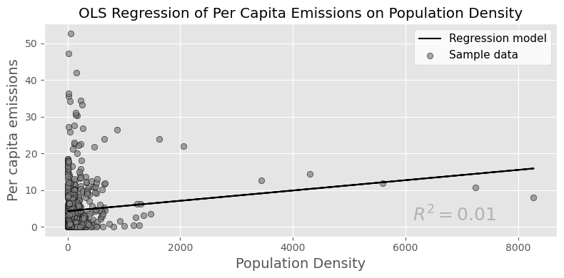

```python
plt.style.use('default')
plt.style.use('ggplot')

fig, ax = plt.subplots(figsize=(8, 4))

ax.plot(X, response, color='k', label='Regression model')
ax.scatter(X, y, edgecolor='k', facecolor='grey', alpha=0.7, label='Sample data')
ax.set_ylabel('Per capita emissions', fontsize=14)
ax.set_xlabel('Population Density', fontsize=14)
ax.text(0.8, 0.1, '$R^2= %.2f$' % r2, fontsize=18, ha='center', va='center',
         transform=ax.transAxes, color='grey', alpha=0.5)
ax.legend(facecolor='white', fontsize=11)
ax.set_title('OLS Regression of Per Capita Emissions on Population Density' )

fig.tight_layout()
```

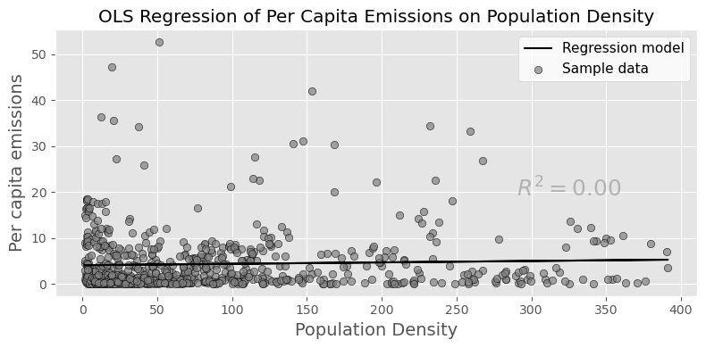

```python
X = Emerged_no_outliers['Population Density'].values.reshape(-1,1)
X = X.astype('float64')
y = Emerged_no_outliers['Per Capita'].values

ols = linear_model.LinearRegression()
model = ols.fit(X, y)
response = model.predict(X)

r2 = model.score(X, y)

plt.style.use('default')
plt.style.use('ggplot')

fig, ax = plt.subplots(figsize=(8, 4))

ax.plot(X, response, color='k', label='Regression model')
ax.scatter(X, y, edgecolor='k', facecolor='grey', alpha=0.7, label='Sample data')
ax.set_ylabel('Per capita emissions', fontsize=14)
ax.set_xlabel('Population Density', fontsize=14)
ax.text(0.8, 0.4, '$R^2= %.2f$' % r2, fontsize=18, ha='center', va='center',
         transform=ax.transAxes, color='grey', alpha=0.5)
ax.legend(facecolor='white', fontsize=11)
ax.set_title('OLS Regression of Per Capita Emissions on Population Density' )

fig.tight_layout()
```

With and without presence of outliers that contribute to noisy results, the relationship between population density and per capita emissions only show R-squared values of around 0, indicating a weak correlation between the two variables' variances. This finding is surprising as one would assume that higher population density would result in more efficient resource use. One reason behind this weak relationship could be the different characteristics population density is picking up. It could be picking up a poorer country, with high fertility rates and low per capita emissions, or a highly urbanized state with high per capita emissions. Density itself depending on the place may have a positive or negative effect on emissions. As we'll see in Yonghong Liu's study, densification was linked with higher emissions, but in a North American situation, when standing opposed to subarbinazation, dense urbanization is actually more energy efficient (rkeil, “Sub/Urbanization and Density: A Few Critical Notes | Global Suburbanisms,” Yorku.ca, February 14, 2014, .).

To better understand the relationship between household size, GDP per capita, population density and per capita emissions we have included a correlation table in this stage of the paper. By controlling for other variables that may impact household size and carbon emissions, we hope to examine the effect of household size on emissions more effectively. Furthermore, this correlation matrix lays the groundwork for the upcoming multivariate regression analysis.

```python
EMERGED_df = pd.merge(Emerged_df, household_data, on=['Country', 'Year'])

EMERGED_df= EMERGED_df.replace(',', '', regex=True)


EMERGED_df['GDP Per Capita'] = EMERGED_df['GDP Per Capita'].astype('float')
EMERGED_df['Population Density'] = EMERGED_df['Population Density'].astype('float')
EMERGED_df['Average household size (number of members)'] = EMERGED_df['Average household size (number of members)'].astype('float')

EMERGED_df.rename(columns={'Per Capita': 'Per Capita Emissions'}, inplace=True)
EMERGED_df
```

|  | Country | ISO 3166-1 alpha-3 | Year | Total | Coal | Oil | Gas | Cement | Flaring | Other | Per Capita Emissions | GDP Per Capita | Population Density | Reference date (dd/mm/yyyy) | Average household size (number of members) | Max_Year |
| --- | --- | --- | --- | --- | --- | --- | --- | --- | --- | --- | --- | --- | --- | --- | --- | --- |
| 0 | Afghanistan | AFG | 2010 | 8.364803 | 2.246032 | 5.833088 | 0.271136 | 0.014547 | 0.000000 | 0.0 | 0.296733 | 631.0 | 44.1 | 2010-01-07 | 7.75 | 2015 |
| 1 | Albania | ALB | 2000 | 3.024926 | 0.069531 | 2.839801 | 0.021957 | 0.093637 | 0.000000 | 0.0 | 0.950630 | 1128.0 | 113.9 | 2000-01-07 | 4.35 | 2017 |
| 2 | Algeria | DZA | 2018 | 173.911594 | 1.330002 | 54.922121 | 88.886635 | 12.381661 | 16.391175 | 0.0 | 4.147961 | 4107.0 | 17.6 | 2018-01-07 | 4.94 | 2018 |
| 3 | Argentina | ARG | 1980 | 108.656928 | 2.865248 | 76.507984 | 19.565760 | 3.562416 | 6.155520 | 0.0 | 3.877170 | 8361.0 | 10.3 | 1980-01-07 | 3.86 | 2019 |
| 4 | Argentina | ARG | 2010 | 186.733136 | 3.990096 | 90.145392 | 86.928400 | 4.178000 | 1.491248 | 0.0 | 4.543372 | 10413.0 | 15.1 | 2010-01-07 | 3.26 | 2019 |
| ... | ... | ... | ... | ... | ... | ... | ... | ... | ... | ... | ... | ... | ... | ... | ... | ... |
| 146 | Zambia | ZMB | 1990 | 2.407113 | 0.831728 | 1.395984 | 0.000000 | 0.179401 | 0.000000 | 0.0 | 0.313165 | 542.0 | 10.8 | 1990-01-07 | 5.85 | 2018 |
| 147 | Zambia | ZMB | 2000 | 1.784113 | 0.289456 | 1.341024 | 0.000000 | 0.153633 | 0.000000 | 0.0 | 0.180375 | 364.0 | 14.2 | 2000-01-07 | 5.24 | 2018 |
| 148 | Zambia | ZMB | 2010 | 3.120300 | 0.381056 | 2.304656 | 0.000000 | 0.434588 | 0.000000 | 0.0 | 0.226238 | 1469.0 | 18.6 | 2010-01-07 | 5.21 | 2018 |
| 149 | Zambia | ZMB | 2018 | 7.412041 | 2.744336 | 3.601712 | 0.000000 | 1.065993 | 0.000000 | 0.0 | 0.415569 | 1475.0 | 23.7 | 2018-01-08 | 5.00 | 2018 |
| 150 | Zimbabwe | ZWE | 2010 | 8.754012 | 6.507264 | 1.938256 | 0.000000 | 0.308492 | 0.000000 | 0.0 | 0.681789 | 976.0 | 36.4 | 2010-12-21 | 4.15 | 2019 |

151 rows × 16 columns

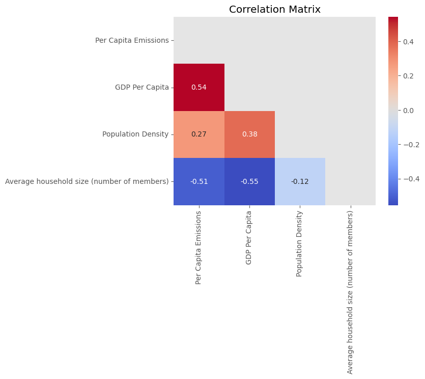

```python
cols = ['Per Capita Emissions','GDP Per Capita', 'Population Density', 'Average household size (number of members)']


corr = EMERGED_df[cols].corr()  # calculate correlation matrix

mask = np.triu(np.ones_like(corr))

# plot the correlation matrix as a heatmap
sn.heatmap(corr, cmap='coolwarm', annot=True, mask = mask)

# set plot title
plt.title('Correlation Matrix')

# display the plot
plt.show()
```

Population's purported link to carbon emissions may be due, in part, to its weak correlation with GDP per capita and the subsequent moderate effect GDP per capita has on per capita emissions. Because of this study’s a global scope, it does not directly contradict Yonghong Liu's 2017 paper ("The impact of urbanization on GHG emissions in China: The role of population density," Journal of Cleaner Production 157 (2017): 299-309), which found that density played a significant role in increasing China's carbon emissions. However, it challenges the possible assumption that this conclusion could be extrapolated and considered universal.

Another intriguing finding is the negative correlation between average household size and population density. One might expect that less space/more density would result in more people living in each housing unit, but the relationship may not be statistically significant once a regression is run. Nevertheless, it is noteworthy that there is no positive relationship between the two. One possible explanation is the pattern of high-density urbanization in developed countries, where smaller households are more common due to cultural reasons, as singles and couples live without members of their extended family.

Below we have plotted the relationships between household size and both GDP per capita and population density to see how they affect per capita emissions. We have also calculated the r-squared of household size on emissions. Surprisingly, we found that both relationships had lower r-squared values compared to the previous regression of household size on per capita emissions (see "Per Capita Emissions and Household Size" plot). Adding more data usually improves the accuracy of the regression, so this result was unexpected. However, upon re-calculating the r-squared of household size on emissions, we found that it was now 0.26, as opposed to the previous value of 0.46. This suggests that the relationship between household size and emissions has been weakened in the merged dataset, possibly due to the presence of other important factors. The merged dataset contains more recent data, mostly due to scarce information on GDP per capita stretching significantly into the past.

[figure not shown]

```python
# Creating dataset
z = EMERGED_df['Per Capita Emissions'].values
x = EMERGED_df['Average household size (number of members)'].values
y = EMERGED_df['Population Density'].values

# Performing multiple linear regression
X = sm.add_constant(np.column_stack((x, y)))
model = sm.OLS(z, X).fit()

# Creating figure
fig = plt.figure(figsize=(10, 7))
ax = plt.axes(projection='3d')

# Creating plot
ax.scatter3D(x, y, z, color='green')
plt.title('GDP Per Capita and Household Size on Per Capita Emissions')
ax.set_ylabel('Population Density')
ax.set_xlabel('Average Household Size')
ax.set_zlabel('Per Capita Emissions')

# Displaying R-squared
R_squared = round(model.rsquared, 2)
R_squared = str(R_squared)
ax.text2D(0.5, 0.5, 'R-squared = ' + R_squared, fontsize=12, transform=ax.transAxes)

# Show plot
plt.show()
```

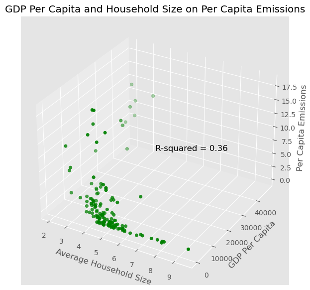

```python
# Creating dataset
z = EMERGED_df['Per Capita Emissions'].values
x = EMERGED_df['Average household size (number of members)'].values
y = EMERGED_df['GDP Per Capita'].values

# Performing multiple linear regression
X = sm.add_constant(np.column_stack((x, y)))
model = sm.OLS(z, X).fit()

# Creating figure
fig = plt.figure(figsize=(10, 7))
ax = plt.axes(projection='3d')

# Creating plot
ax.scatter3D(x, y, z, color='green')
plt.title('GDP Per Capita and Household Size on Per Capita Emissions')
ax.set_ylabel('GDP Per Capita')
ax.set_xlabel('Average Household Size')
ax.set_zlabel('Per Capita Emissions')

# Displaying R-squared
R_squared = round(model.rsquared, 2)
R_squared = str(R_squared)
ax.text2D(0.5, 0.5, 'R-squared = ' + R_squared, fontsize=12, transform=ax.transAxes)

# Show plot
plt.show()
```

```python
# x and y are your variables of interest
x = EMERGED_df['Average household size (number of members)'].values
y = EMERGED_df['Per Capita Emissions'].values

# Calculate the slope, intercept, correlation coefficient, p-value, and standard error of the regression coefficients
slope, intercept, rvalue, pvalue, stderr = linregress(x, y)

# Calculate R-squared value
r_squared = rvalue**2

print("R-squared:", r_squared)
```

```
R-squared: 0.26006823552686276
```

# OLS Regression

## 4.1

At first glance, the relationship between household size and carbon emissions would seem to be linear; as more people cram into the same space there should be just more energy efficiency, even if we deal with the collinearity it has with GDP per capita. However, if we look at the household size and Per Capita emissions plot we can see that there is a negative linear relationship, until the household size reaches 5 people; once it reaches this point the relationship disappears as the line of best fit becomes almost completely horizontal.

The reasons why this could be the case are numerous. For one, there may be a decreasing marginal efficiency that one achieves within the household. For example, with four people in the household instead of two, the same appliances can be used but at a higher capacity rate. With more than five people, these inefficiencies may dissipate as families may have to buy more appliances and use some of them at similar capacity rates as a two-person household.

There's also factors external to the household that are influenced by holding high household sizes. First off, more than five people in a household may be indicative of bad urban planning whereby communities are dense but also chaotic, leading to higher per capita carbon emissions as energy, transportation and resources are not allocated efficiently. This can be tied back to Jevon's paradox, where an increase in the efficiency of resource use leads to an increase in that resource's consumption rather than a decrease. In this case, the efficiencies brought by denser households lead to an increase in energy consumption and a leveling off of the negative effect density had on carbon emissions.

## 4.2

For the X's we choose for the following regressions, they will mostly consist of variables that have already been mentioned. Earlier in the report, oil emissions were singled out as a potential substitute for coal, and could yield an accurate regression with significant effects on per capita emissions. Other emissions will also be used for this purpose, depending on their source, which may come from low-carbon renewable sources like solar panel or wind turbine production, or higher carbon sources like biomass. A regression would help clarify this relationship.

In addition, household size is the main variable being studied in this paper. As explained previously, the effect of household size on emissions could depend on a multitude of factors such as energy efficiency in the region, type of building, as well as its collinearity with density and GDP per capita. For this reason, these two variables will be included as fixed effects and x variables, to determine the effect of these important factors on emissions.

## First Emissions Regression

For this regression we'll be looking at the relationship all the different sources have on total emissions. At first glance it seems as if the relationship will be merely positive. Obviously an increase in emissions of any type will have an increase in total emissions or per capita emissions, if the relationships between different emissions sources are ignored. However, in this first regression we'll seek to identify whether any of the sources does not have a significant impact on total emissions, or, even a significant negative coefficient when it comes to its effect on total emissions. We'll also be using per capita emissions as our "y" value since it will be less affected by external factors, especially population growth.

For the following regression the specification is as follows:

$$ Per Capita Emissions = \beta_0 + \beta_1 \text{Coal}+ \beta_2 \text{Oil} + \beta_3 \text{Gas} + \beta_4 \text{Cement} + \beta_4 \text{Flaring} + \beta_5 \text{Other} + \epsilon $$

```python
emissions_data_clean
```

|  | Country | ISO 3166-1 alpha-3 | Year | Total | Coal | Oil | Gas | Cement | Flaring | Other | Per Capita |
| --- | --- | --- | --- | --- | --- | --- | --- | --- | --- | --- | --- |
| 199 | Afghanistan | AFG | 1949 | 0.014656 | 0.014656 | 0.000000 | 0.000000 | 0.000000 | 0.000000 | 0.000000 | 0.000000 |
| 200 | Afghanistan | AFG | 1950 | 0.084272 | 0.021068 | 0.063204 | 0.000000 | 0.000000 | 0.000000 | 0.000000 | 0.011266 |
| 201 | Afghanistan | AFG | 1951 | 0.091600 | 0.025648 | 0.065952 | 0.000000 | 0.000000 | 0.000000 | 0.000000 | 0.012098 |
| 202 | Afghanistan | AFG | 1952 | 0.091600 | 0.031708 | 0.059892 | 0.000000 | 0.000000 | 0.000000 | 0.000000 | 0.011946 |
| 203 | Afghanistan | AFG | 1953 | 0.106256 | 0.037949 | 0.068307 | 0.000000 | 0.000000 | 0.000000 | 0.000000 | 0.013685 |
| ... | ... | ... | ... | ... | ... | ... | ... | ... | ... | ... | ... |
| 63099 | Global | WLD | 2017 | 36096.739276 | 14506.973805 | 12242.627935 | 7144.928128 | 1507.923185 | 391.992176 | 302.294047 | 4.749682 |
| 63100 | Global | WLD | 2018 | 36826.506600 | 14746.830688 | 12266.016285 | 7529.846784 | 1569.218392 | 412.115746 | 302.478706 | 4.792753 |
| 63101 | Global | WLD | 2019 | 37082.558969 | 14725.978025 | 12345.653374 | 7647.528220 | 1617.506786 | 439.253991 | 306.638573 | 4.775633 |
| 63102 | Global | WLD | 2020 | 35264.085734 | 14174.564010 | 11191.808551 | 7556.290283 | 1637.537532 | 407.583673 | 296.301685 | 4.497423 |
| 63103 | Global | WLD | 2021 | 37123.850352 | 14979.598083 | 11837.159116 | 7921.829472 | 1672.592372 | 416.525563 | 296.145746 | 4.693699 |

21697 rows × 11 columns

```python
emissions_data_clean['const'] = 1

x = emissions_data_clean[['const','Coal', 'Oil', 'Cement', 'Flaring', 'Other', 'Gas']]

reg1 = sm.OLS(endog=emissions_data_clean['Per Capita'], exog= x,
             missing = 'drop')
results = reg1.fit()
results.summary()
```

OLS Regression Results

| Dep. Variable: | Per Capita | R-squared: | 0.002 |
| --- | --- | --- | --- |
| Model: | OLS | Adj. R-squared: | 0.002 |
| Method: | Least Squares | F-statistic: | 8.980 |
| Date: | Sun, 16 Apr 2023 | Prob (F-statistic): | 8.03e-10 |
| Time: | 23:29:32 | Log-Likelihood: | -91409. |
| No. Observations: | 21697 | AIC: | 1.828e+05 |
| Df Residuals: | 21690 | BIC: | 1.829e+05 |
| Df Model: | 6 |  |  |
| Covariance Type: | nonrobust |  |  |

|  | coef | std err | t | P>\|t\| | [0.025 | 0.975] |
| --- | --- | --- | --- | --- | --- | --- |
| const | 3.7913 | 0.112 | 33.789 | 0.000 | 3.571 | 4.011 |
| Coal | 0.0023 | 0.001 | 3.655 | 0.000 | 0.001 | 0.004 |
| Oil | -0.0039 | 0.001 | -3.471 | 0.001 | -0.006 | -0.002 |
| Cement | -0.0420 | 0.009 | -4.768 | 0.000 | -0.059 | -0.025 |
| Flaring | 0.0218 | 0.020 | 1.066 | 0.286 | -0.018 | 0.062 |
| Other | 0.0114 | 0.029 | 0.393 | 0.694 | -0.045 | 0.068 |
| Gas | 0.0102 | 0.002 | 5.127 | 0.000 | 0.006 | 0.014 |

| Omnibus: | 55584.450 | Durbin-Watson: | 0.152 |
| --- | --- | --- | --- |
| Prob(Omnibus): | 0.000 | Jarque-Bera (JB): | 1146857712.470 |
| Skew: | 29.130 | Prob(JB): | 0.00 |
| Kurtosis: | 1127.809 | Cond. No. | 825. |

Notes:  
[1] Standard Errors assume that the covariance matrix of the errors is correctly specified.

```python
from IPython.core.display import HTML

stargazer = Stargazer([results])
stargazer.custom_columns(["Per Capita Emissions"],[1])
HTML(stargazer.render_html())
```

|  | *Dependent variable:Per Capita* |
| --- | --- |
|  | Per Capita Emissions |
|  | (1) |
| Cement | -0.042*** |
|  | (0.009) |
| Coal | 0.002*** |
|  | (0.001) |
| Flaring | 0.022 |
|  | (0.020) |
| Gas | 0.010*** |
|  | (0.002) |
| Oil | -0.004*** |
|  | (0.001) |
| Other | 0.011 |
|  | (0.029) |
| const | 3.791*** |
|  | (0.112) |
| Observations | 21,697 |
| R<sup>2</sup> | 0.002 |
| Adjusted R<sup>2</sup> | 0.002 |
| Residual Std. Error | 16.350 (df=21690) |
| F Statistic | 8.980*** (df=6; 21690) |
| Note: | *p<0.1; **p<0.05; ***p<0.01 |

```python
results.mse_resid
```

```
267.3089915442852
```

### Regression Evaluation

The regression has an R-squared of 0.002 which is lower than all the previous regressions run and means that very little of the variation of per capita emissions can be explained through the variation in the different emission sources. Although it must be measured against other models to determine its validity, this regressions AIC is also extremely high, meaning the model does not have a great fit or may be overparameterized; This weakens any conclusions that can be brought out from the regression table.

## Regression #2: Adding a quadratic effect for Oil

This regression will be the exact same as the regression above except for the inclusion of a quadratic effect for Oil, which is added to help determine the exact shape of Oil's effect on total emissions. We predict that it may have a quadratic effect, as a slight increase in oil emissions might represent a substitution away from coal and more pollutant sources. This was described in H Bloch et al's. 2015 Fuel Substitution paper (H Bloch, Shuddhasattwa Rafiq, and Ruhul Salim, “Economic Growth with Coal, Oil and Renewable Energy Consumption in China: Prospects for Fuel Substitution,” Economic Modelling ( , 2015)) where it was found that oil's effect on emissions was close to negligible, because it represented a substitution away from coal dependency.

For the following regression the specification will be as follows:

$$ Per Capita Emissions = \beta_0 + \beta_1 \text{Coal}+ \beta_2 \text{Oil} + \beta_3 \text{Oil}^{2} + \beta_4 \text{Gas} + \beta_5 \text{Cement} + \beta_6 \text{Flaring} + \beta_7 \text{Other} + \epsilon $$

We have included both a linear and a quadratic term for oil in our regression specification to make the model more flexible and capture different shapes of the relationship. Although we have predicted that the effect of oil on per capita emissions is quadratic, it is possible that the relationship may not be strictly parabolic. Thus, including the linear term allows us to account for any potential linearities in the relationship and ensures that our model captures a wider range of possible shapes of the relationship between oil and per capita emissions.

```python
X = emissions_data_clean[['Oil', 'Coal', 'Gas', 'Cement', 'Flaring', 'Other']]
X['Oil_squared'] = X['Oil']**2
X = sm.add_constant(X)

# fit the OLS model
reg1_2 = sm.OLS(endog=emissions_data_clean['Per Capita'], exog=X, missing='drop')
results = reg1_2.fit()

stargazer = Stargazer([results])
stargazer.custom_columns(["Per Capita Emissions"],[1])
HTML(stargazer.render_html())
```

|  | *Dependent variable:Per Capita* |
| --- | --- |
|  | Per Capita Emissions |
|  | (1) |
| Cement | -0.011 |
|  | (0.009) |
| Coal | 0.000 |
|  | (0.001) |
| Flaring | 0.084*** |
|  | (0.021) |
| Gas | 0.016*** |
|  | (0.002) |
| Oil | 0.001 |
|  | (0.001) |
| Oil_squared | -0.000*** |
|  | (0.000) |
| Other | 0.016 |
|  | (0.029) |
| const | 3.595*** |
|  | (0.114) |
| Observations | 21,697 |
| R<sup>2</sup> | 0.007 |
| Adjusted R<sup>2</sup> | 0.007 |
| Residual Std. Error | 16.310 (df=21689) |
| F Statistic | 23.017*** (df=7; 21689) |
| Note: | *p<0.1; **p<0.05; ***p<0.01 |

```python
results.mse_resid
```

```
266.00930136269653
```

## Regression Evaluation

The R^2 of the regression increased by 0.005 and the MSE decreased by around 1.3, meaning that adding the oil_squared coefficient does help explain more of the variance in the data and may be a hint that the shape of oil's coefficient isn't linear. Nevertheless, an R^2 of 0.007 is still very low and means that although some results may be significant, they effect a very small part of per capita emissions, making the relationship insignificant in terms of actual conclusions on how to solve the climate crisis.

## Regression Takeaways

Despite the low significance and relatively high MSE, we were able to identify significant variables that affect per capita emissions, including flaring, gas, and oil. Our findings align with those of H. Bloch et al., who observed a negligible effect of increasing oil emissions on total emissions. However, the addition of a quadratic term for oil emissions led to a decrease in the significance of coal, which contradicts our initial hypothesis about the relationship between coal and oil. Future regressions will be conducted to further explore this relationship.

## Regression #3: Introducing Urbanization Characteristics

Given that so far we have found that sources of emissions are fairly low predictors of actual per capita emissions, we will now have to turn towards urban characteristics, which is the main topic of our paper, to see whether regressions including these factors are better predictors. The decision for why these variables have been included have been explored in depth in sections 2.1, 3.1 and 3.6.

The specification is as follows: $$ Per Capita Emissions = \beta_0 + \beta_1 \text{Household Size}+ \beta_2 \text{GDP Per Capita} + \beta_3 \text{Density} + \epsilon $$

```python
EMERGED_df['const'] = 1

x = EMERGED_df[['const','GDP Per Capita', 'Population Density', 'Average household size (number of members)']]

reg2 = sm.OLS(endog=EMERGED_df['Per Capita Emissions'], exog= x,
             missing = 'drop')
results1 = reg2.fit()
stargazer = Stargazer([results])
stargazer.custom_columns(["Per Capita Emissions"],[1])
HTML(stargazer.render_html())
```

[output not shown]

```python
results.mse_resid
```

[output not shown]

## Regression Takeaways

In contrast, the regression shows that GDP per capita has a significant null effect, which is contrary to what was shown in the correlation matrix. This means that although there was a correlation between higher GDP per capita and higher per capita emissions, it was not a causal relationship and could have been influenced by its interaction with another variable, most likely average household size (as shown in the correlation matrix where they had a -0.55 correlation), as well as other variables not included in the analysis.

Lastly, population density was found to have an insignificant, close to null effect, which highlights the important distinction between household size and density.

## Regression #4: GDP per Capita Fixed Effects

Due to the correlation between household size and GDP per capita, and the unexpected significant null effect of GDP per capita on per capita emissions found in the previous regression, we aim to disentangle the effects of GDP per Capita and household size through the inclusion of fixed effects. By controlling for the impact of GDP per Capita on emissions through household size, which may have been acting as an exogenous variable in the previous regression, we can better understand the individual effects of these variables on per capita emissions.

The correlation for the following is as follows:

$$ Per Capita Emissions = \beta_0 + \beta_1 \text{Household Size}+ \beta_2 \text{Density} + \delta_1\text{0-1000 per capita} + \delta_2\text{1000-2000 per capita} + \delta_3\text{2000 < per capita} + \epsilon $$

The ranges for the fixed effects were selected based on the median GDP per capita of the countries in the dataset, which was only $1,600. This relatively low median can be attributed to the fact that the dataset includes many developing countries and contains time-series data that spans several decades, including many recently independent states that were beginning to form modern institutions and had comparatively lower living standards than the developed nations of the time.

```python
EMERGED_df['GDP Per Capita'].median()
```

```
1637.0
```

```python
# Create dummy variables for GDP per capita ranges
EMERGED_df['GDP_Range_< 1000'] = np.where(EMERGED_df['GDP Per Capita'] < 1000, 1, 0)
EMERGED_df['GDP_Range_2000 > 1000'] = np.where((EMERGED_df['GDP Per Capita'] >= 1000) & (EMERGED_df['GDP Per Capita'] < 2000), 1, 0)
EMERGED_df['GDP_Range_>2000'] = np.where(EMERGED_df['GDP Per Capita'] >= 2000, 1, 0)

# Create the regression model with fixed effects
x = EMERGED_df[['const', 'Population Density', 'Average household size (number of members)', 'GDP_Range_< 1000', 'GDP_Range_2000 > 1000', 'GDP_Range_>2000']]
reg3 = sm.OLS(endog=EMERGED_df['Per Capita Emissions'], exog=x, missing='drop')
results2 = reg3.fit()

# Display the regression results using stargazer
stargazer = Stargazer([results])
stargazer.custom_columns(["Per Capita Emissions"],[1])
HTML(stargazer.render_html())
```

[output not shown]

```python
results.mse_resid
```

[output not shown]

## Regression Takeaways

We can immediately see that the household size effect has decreased meaning that some of its effect on emissions had to do with its correlation or negative correlation with household size. Nevertheless, the effect remains significant at the 1% level.

## Regression #5 Oil Emissions

Given the significant impact of oil emissions on total emissions, and the need for a more nuanced understanding of how household size affects emissions, we will also examine the effect of household size on oil emissions. This regression was motivated by Alkhatlan and Javid's 2015 study (Khalid Alkhathlan and Muhammad Javid, “Carbon Emissions and Oil Consumption in Saudi Arabia,” Renewable and Sustainable Energy Reviews 48 (August 2015): 105–11,), which investigated the association between increased wealth and higher oil consumption and emissions. Although the issue of endogeneity could affect the results of that study because of the characteristics of the country, our regression seeks to test this relationship on a global scale with an OLS.

The specification for the regression is as follows: $$ Oil Emissions = \beta_0 + \beta_1 \text{Household Size} + \delta_1\text{0-1000 per capita} + \delta_2\text{1000-2000 per capita} + \delta_3\text{>2000 per capita}\epsilon $$

```python
merged_df = pd.DataFrame()
merged_df
```

```python
merged_df = pd.merge(household_data, emerged_df, on=['Country', 'Year'])

merged_df['GDP Per Capita'] = merged_df["GDP Per Capita"].str.replace(',', '').replace('', np.nan).astype(float)
```

[output not shown]

```python
merged_df['Oil'] = merged_df['Oil'].dropna()
merged_df['Average household size (number of members)'] = merged_df['Average household size (number of members)'].astype(float)
```

```python
# Create dummy variables for GDP per capita ranges
merged_df['GDP_Range_< 1000'] = np.where(merged_df['GDP Per Capita'] < 1000, 1, 0)
merged_df['GDP_Range_2000 > 1000'] = np.where((merged_df['GDP Per Capita'] >= 1000) & (merged_df['GDP Per Capita'] < 2000), 1, 0)
merged_df['GDP_Range_>2000'] = np.where(merged_df['GDP Per Capita'] >= 2000, 1, 0)

# Create the regression model with fixed effects
x = merged_df[['const','Average household size (number of members)', 'GDP_Range_< 1000', 'GDP_Range_2000 > 1000', 'GDP_Range_>2000']]
reg4 = sm.OLS(endog=merged_df['Oil'], exog=x, missing='drop')
results = reg4.fit()

# Display the regression results using stargazer
stargazer = Stargazer([results])
stargazer.custom_columns(["Oil Emissions"],[1])
HTML(stargazer.render_html())
```

[output not shown]

```python
results.mse_resid
```

[output not shown]

## Regression Conclusion

However, because of the linearity assumptions of the OLS regression, a more accurate model is needed to capture the main effects of emission sources, especially oil. The eventual goal is to potentially create an IV where the exogenous variable is household size, the instrument is either coal or oil, and the endogenous variable is per capita emissions. In order for this IV model to be included, further research is required to confirm that the specification satisfies the three assumptions: that household size is exogenous, that it is relevant, and that it only affects per capita emissions through coal/oil emissions.

# Machine Learning

In this section we'll use a machine learning algorithm to determine, first the effects each source has on total emissions and then the effects specific characteristics of urban planning have on emissions. We're in theory, looking at and attempting to quantify the same things we examined in the previous linear regression section, however, now we're able to quantify these effects in non-linear ways because of the way the decision tree functions, where each internal node represents a decision based on a predictor variable and each leaf node represents the predicted value of the response variable.

In this case, there's no reason to suggest that, for example, the relationship between oil emissions and total emissions must be linear. It could be hypothesized that small number of oil emissions could decrease total emissions as it represents a shift from the more pollutnt coal emissions, but that as the amount of oil emissions increases it could also represent a growing dependence on the energy source at the expense of low carbon, renewable energy sources. This type of reasoning could exist for multiple variables (Density for example) and highlights the need for a model that can map more complex relationships.

For the all the regression trees the model will seek to reduce MSE at every node making the specification the relationship below:

$$ \min_{j,s} \left[ \sum_{i: x_{i,j} \leq s, x_i \in R1} (y_i - \hat{y}_{R1})^2 + \sum_{i: x_{i,j} > s, x_i \in R2} (y_i - \hat{y}_{R2})^2 \right] $$

It'll then stop when $ |R| = $ some chosen minimum size or when depth of tree $ = $ some chosen maximum.

$$ \min_{tree \subset T} \sum (\hat{f}(x)-y)^2 + \alpha|\text{terminal nodes in tree}| $$

To optimize the accuracy of the regression tree while maintaining its interpretability and graphical clarity, a maximum depth of 4 will be selected as the regularization parameter, thereby minimizing the mean squared error. Anything higher, would be very difficult to graph, as well as risk overfitting the data.

```python
X = emissions_data_clean.drop(["Country", "ISO 3166-1 alpha-3", "Year", "Total", "Per Capita"], axis=1).copy()
y = emissions_data_clean["Per Capita"]

Emissions_tree = tree.DecisionTreeRegressor(max_depth = 4).fit(X, y)
y_pred_tree = Emissions_tree.predict(X)
print ("Mean Squared Error:", metrics.mean_squared_error(y, y_pred_tree))
```

[output not shown]

```python
Emissions_figure = plt.figure(figsize=(50, 50))
Emissions_figure = tree.plot_tree(Emissions_tree, feature_names=X.columns, filled=True)
```

[output not shown]

Lastly, it is important to note the absence of "other" emissions in the table. In none of the 15 nodes is it mentioned, meaning it most likely has a small effect on total emissions, most likely due to their small overall emissions, or they are not sufficiently correlated with a certain range of emissions of another emissions source.

## Bootstrap Aggregation

Below we will seek to fit multiple trees onto the bootstrapped data in order to come up with a more accurate model with a smaller MSE. We chose the maximum features to be equal to the number of different sources in our emissions table, as well as maintaining the random state at 1 to ensure replicability.

```python
regr1 = RandomForestRegressor(max_features= 6, random_state=1)
regr1.fit(X, y)

pred = regr1.predict(X)

plt.scatter(pred, y, label='Per Capita')
plt.plot([0, 1], [0, 1], '--k', transform=plt.gca().transAxes)
plt.xlabel('pred')
plt.ylabel('y')


mean_squared_error(y, pred)
```

[output not shown]

```python
r2_score(y, pred)
```

[output not shown]

```python
Importance = pd.DataFrame({'Importance':regr1.feature_importances_*100}, index=X.columns)
Importance.sort_values('Importance', axis=0, ascending=True).plot(kind='barh', color='black', )
plt.xlabel('Variable Importance')
plt.gca().legend_ = None
```

[output not shown]

## Bagging Urban Characteristics

Below we'll also seek to perform a similar random forest on the impact of urban characteristics on per capita emissions. It'll have the same specification as above, as the bootstrapping method makes no assumptions as to the linearity of variable's effect, or the population distribution. Rather it simply keeps on creaitng samples, running regressions on them to estimate a regression with lowest MSE

```python
X = EMERGED_df[['const','GDP Per Capita', 'Population Density', 'Average household size (number of members)']]
y = EMERGED_df['Per Capita Emissions']

regr2 = RandomForestRegressor(max_features= 4, random_state=1)
regr2.fit(X, y)

pred = regr2.predict(X)
mse = mean_squared_error(y, pred)

plt.scatter(pred, y, label='Per Capita')
plt.plot([0, 1], [0, 1], '--k', transform=plt.gca().transAxes)
plt.xlabel('pred')
plt.ylabel('y')
plt.text(0.05, 0.9, f"MSE = {mse:.2f}", transform=plt.gca().transAxes)

plt.show()
```

[output not shown]

```python
r2_score(y, pred)
```

[output not shown]

```python
Importance = pd.DataFrame({'Importance':regr2.feature_importances_*100}, index=X.columns)
Importance.sort_values('Importance', axis=0, ascending=True).plot(kind='barh', color='b', )
plt.xlabel('Variable Importance')
plt.gca().legend_ = None
```

[output not shown]

It is important to note that the relatively low contribution of household size to the model does not necessarily disprove our thesis. While it only explains around 20% of the variance in emissions in our model, household size could still be a significant factor in understanding emission patterns and developing effective strategies to reduce total emissions and mitigate the impact of climate change. This is particularly relevant given the dearth of research on this factor in the context of climate change. Therefore, further investigation and exploration of the potential role of household size in driving emissions is warranted.

## Conclusion

### Results

For the second point we can look at regressions 3,4 and to a certain extent 5 as well, as thye demonstrate the robust effect of household size when different variables are included. We get to see that in all these regressions household size has a negative effect on emissions, whether that be total or oil emissions. These figures confirm Ellsworth-Krebs results on floor space and energy efficienc and builds upon her conclusion y by including the types of emissions that influence per capita emissions the most, as well as controlling for wealth and density,

### Discussion and Next Steps

In order to provide more concrete policy recommendations, further research is necessary to determine the exact mechanism through which household size impacts emissions. One potential direction for future research is to explore the relationship between household size and oil emissions, given the latter's outsized influence and potential as an exogenous variable between household size and emissions. However, to establish household size's exogeneity to per capita emissions, relevance to oil emissions, and to prove the exclusion restriction is valid, more data and interpretation are needed. This paper provides an initial exploration of this topic, as seen in regression #5.

Other potential avenues for future research could include investigating the relationship between mean climate and energy consumption (to control for AC and heating energy usage), examining the relationship between car usage and density or household emissions, or even exploring the impact of government type on emission sources (such as whether dictatorships may prioritize economic development over the common good).